# HuGen Session 3 : Alternative ggplot2 tutorial

#### Dodge, Stack and Fill

To demonstrate how dodge, stack and fill work, let’s create an additional categorical variable. Dur_cat will equal TRUE if the duration is greater than the mean, and FALSE otherwise.

```r
I_subset$Dur_cat <- I_subset$Dur_msec > mean(I_subset$Dur_msec)
```

As a first step, we can create a bar plot where the height of the bars is equal to the number of observations in each category.

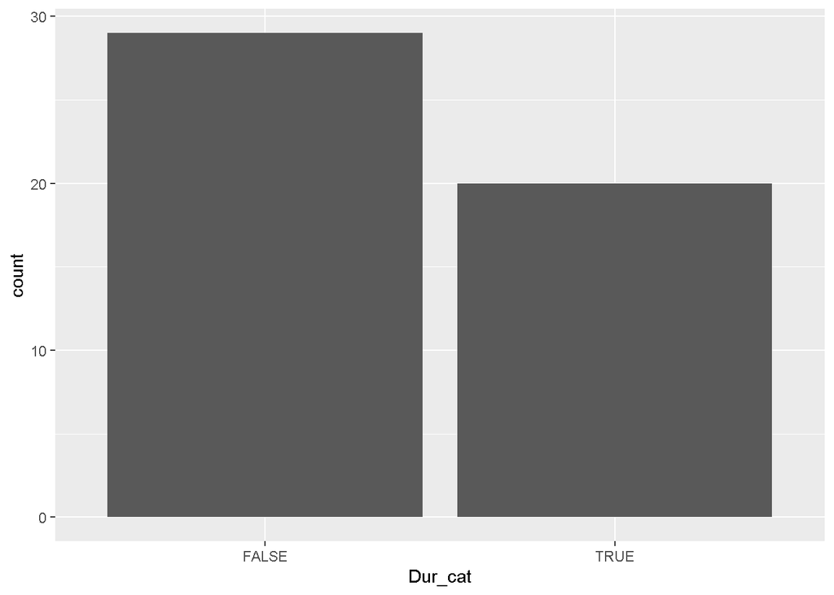

```r
ggplot(I_subset, aes(Dur_cat))+
  geom_bar()
```

Next, we’ll fill in the bars according to Word.

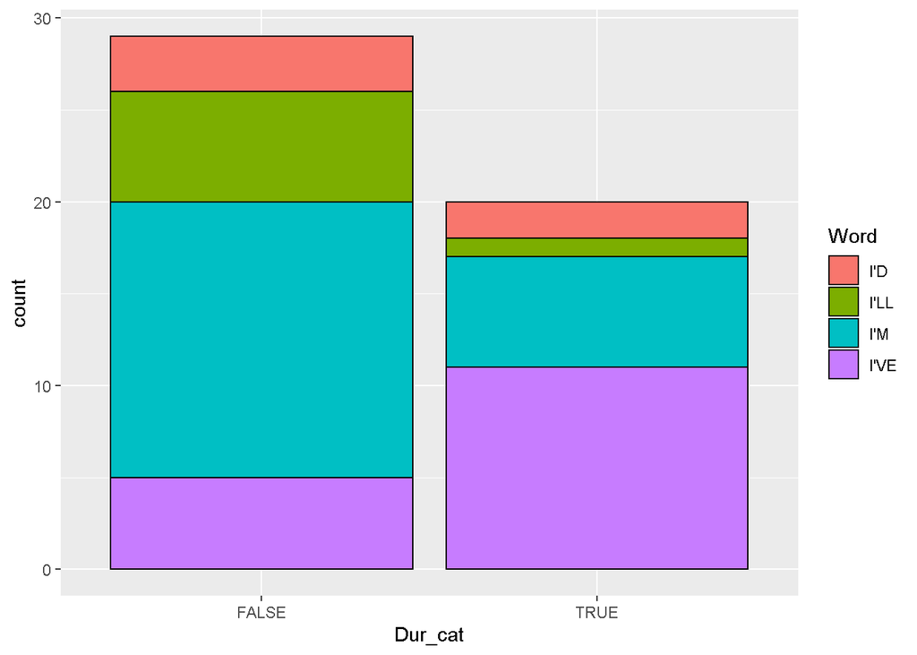

```r
ggplot(I_subset, aes(Dur_cat, fill = Word))+
  geom_bar(color = "black")
```

Here, we’re seeing the default behavior of stacking bars on top of each other. But perhaps we’d like to see each colored segment lined up next to the others in a grouped bar chart. We can do this by defining position = “dodge”.

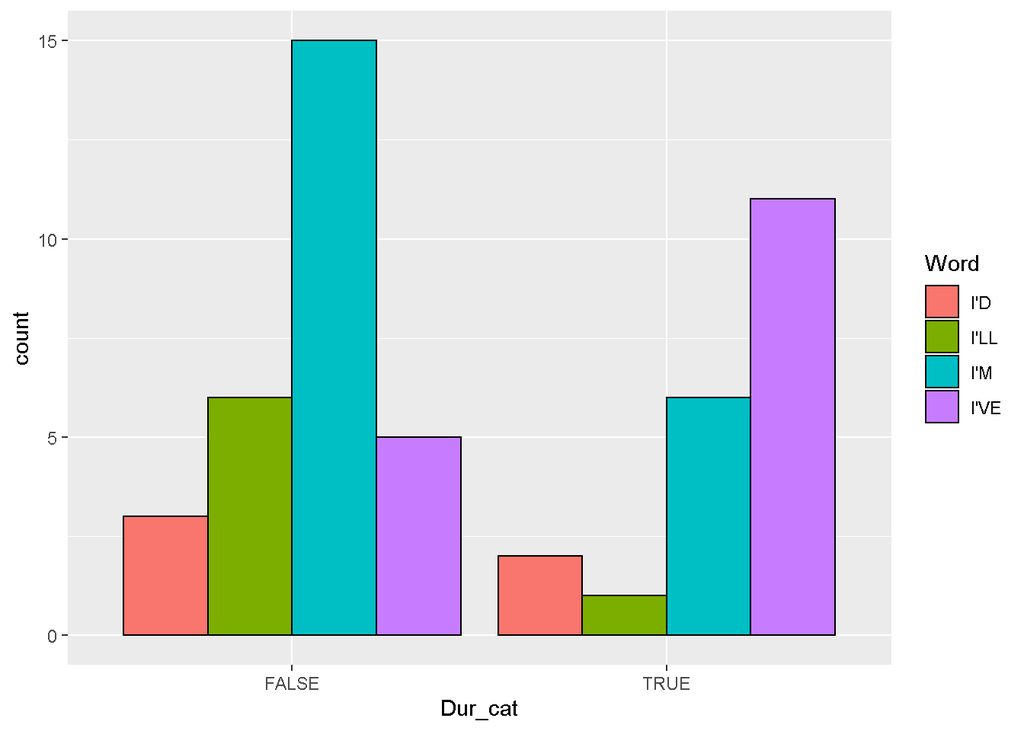

```r
ggplot(I_subset, aes(Dur_cat, fill = Word))+
  geom_bar(position = "dodge", color = "black")
```

Or, perhaps we’d like to scale the stacked bars to be between 0 and 1, so we can more clearly see the proportional distribution of words into long and short categories. We can do this with position = “fill”.

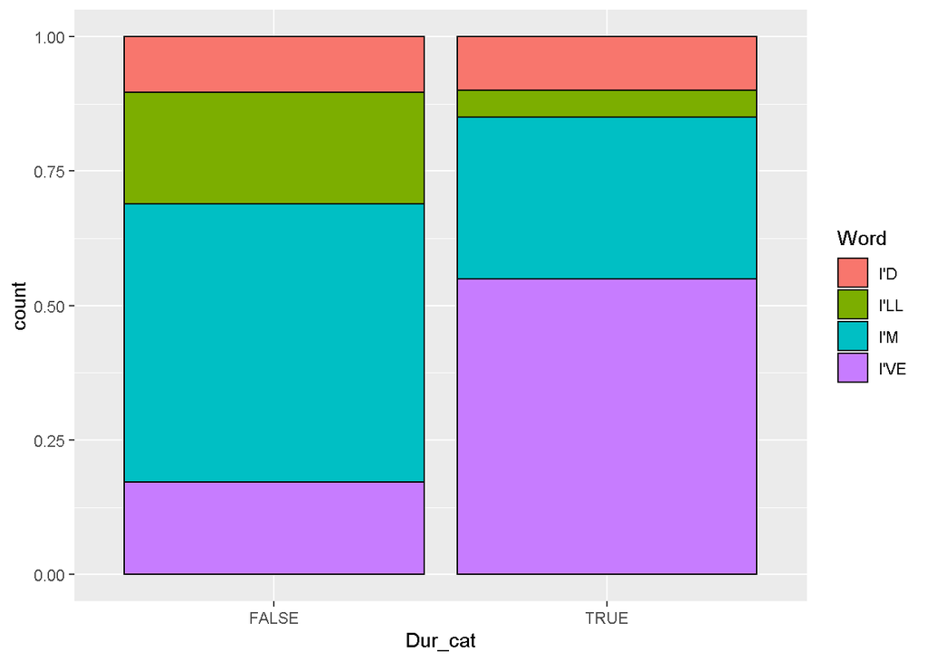

```r
ggplot(I_subset, aes(Dur_cat, fill = Word))+
  geom_bar(position = "fill", color = "black")
```

Or, depending on what kind of information you want to show:

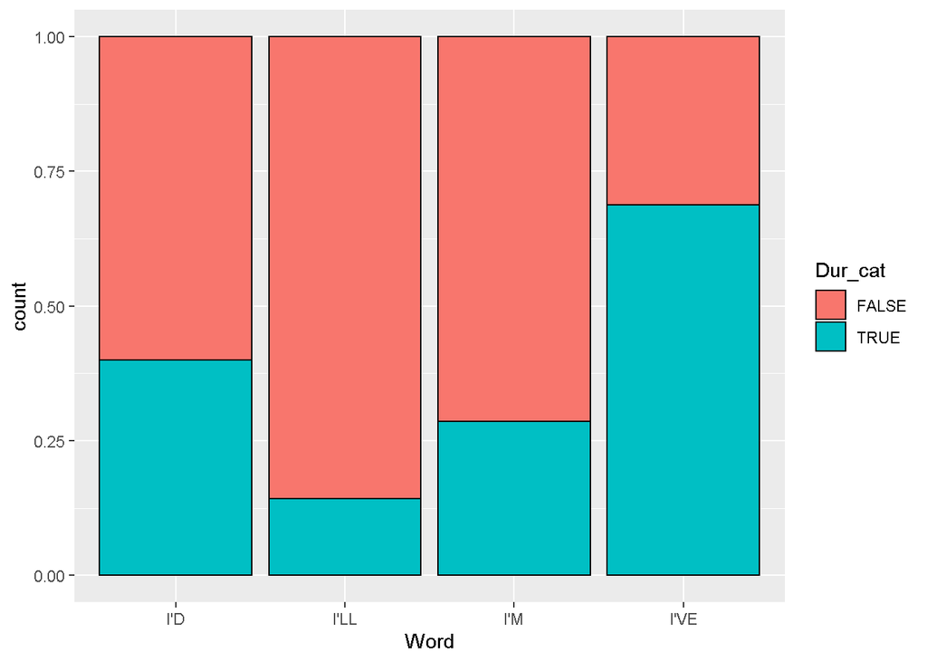

```r
ggplot(I_subset, aes(Word, fill = Dur_cat))+
  geom_bar(position = "fill", color = "black")
```

Stacking and filling are not just only applicable to bars. Things can get really interesting if you apply them to density plots. For example, here are kernel density estimates forDur_msec for each word.

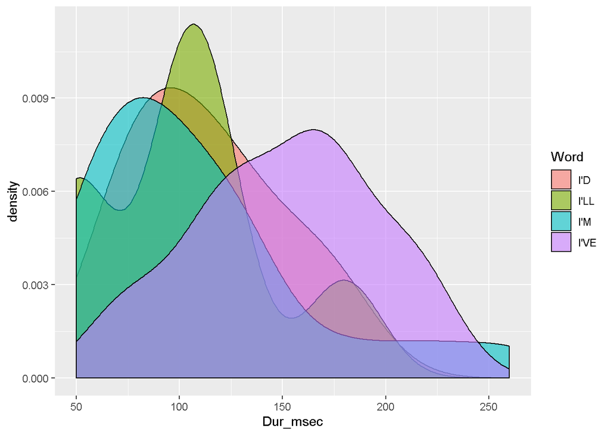

```r
ggplot(I_subset, aes(Dur_msec, fill = Word))+
  geom_density(alpha = 0.6)
```

It’s a bit of a mishmash, but it gets a lot more interesting if you stack them. The bit about y = ..count.. will make more sense when we go over statistics.

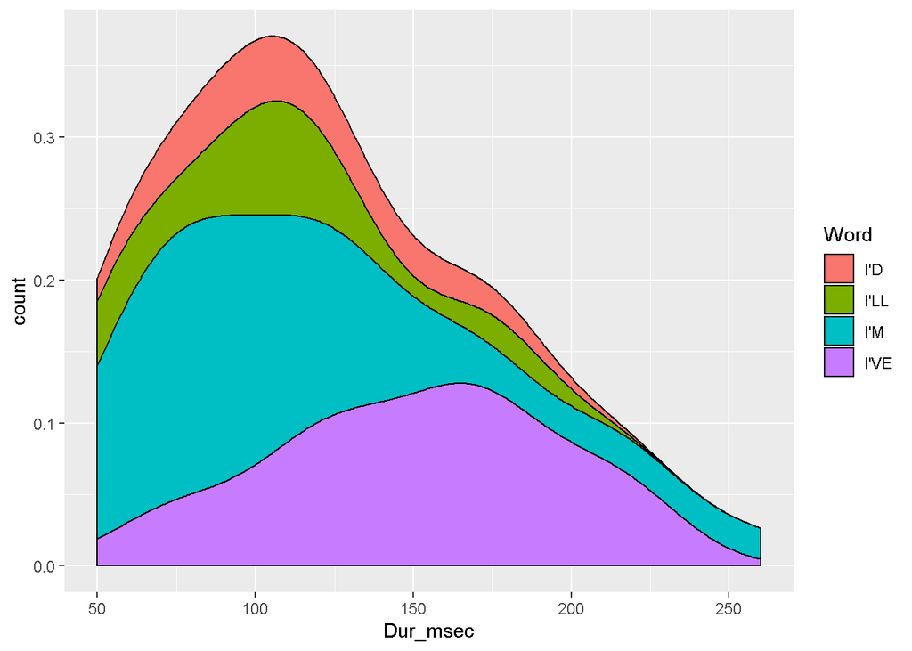

```r
ggplot(I_subset, aes(Dur_msec, fill = Word))+
  geom_density(position = "stack", aes(y = ..count..))
```

Alternatively, we could set position = “fill” to display what proportion of observations at each duration are from which words.

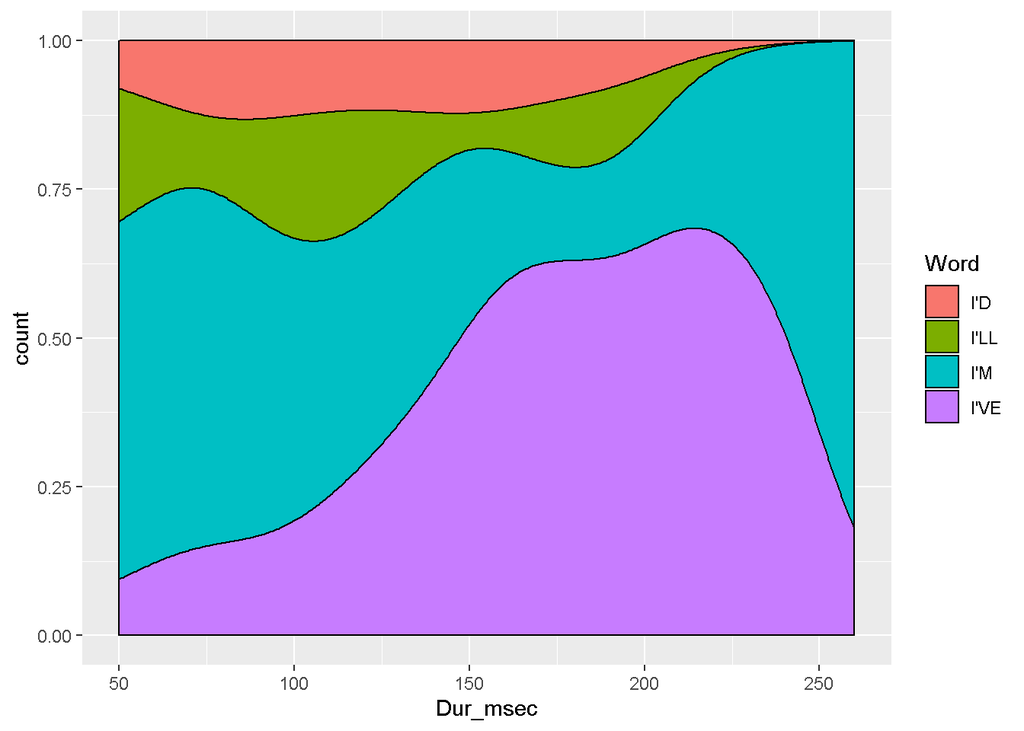

```r
ggplot(I_subset, aes(Dur_msec, fill = Word))+
  geom_density(position = "fill", aes(y = ..count..))
```

#### Some new and exciting geoms

As of version 0.9.0 of ggplot2, there are some new and exciting geoms available, like geom_dotplot() and geom_violin(). Here’s a combination of both geom_violin() and geom_dotplot() that creates a variant of a bean plot.

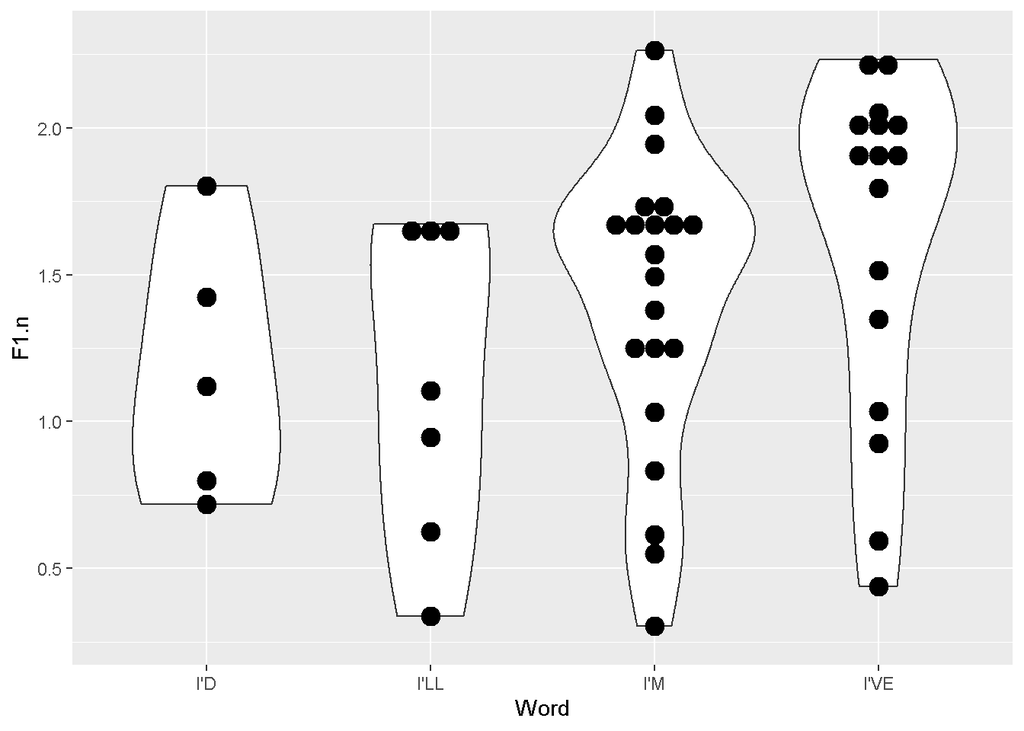

```r
ggplot(I_subset, aes(Word, F1.n))+
  geom_violin()+
  geom_dotplot(binaxis="y", stackdir="center")
```

## Statistics

After the layering paradigm, and the inheritance of aesthetic mappings, the next most powerful aspect of ggplot2 is the ease with which statistical summaries can be incorporated into plots. Every statistical layer you can add to a plot starts with stat_, meaning we can list all statistical layers with apropos().

```r
apropos("^stat_")
```

```
##  [1] "stat_bin"            "stat_bin_2d"         "stat_bin_hex"
##  [4] "stat_bin2d"          "stat_binhex"         "stat_boxplot"
##  [7] "stat_contour"        "stat_count"          "stat_density"
## [10] "stat_density_2d"     "stat_density2d"      "stat_ecdf"
## [13] "stat_ellipse"        "stat_function"       "stat_identity"
## [16] "stat_qq"             "stat_qq_line"        "stat_quantile"
## [19] "stat_sf"             "stat_sf_coordinates" "stat_smooth"
## [22] "stat_spoke"          "stat_sum"            "stat_summary"
## [25] "stat_summary_2d"     "stat_summary_bin"    "stat_summary_hex"
## [28] "stat_summary2d"      "stat_unique"         "stat_ydensity"
```

There are fewer statistical layers than geometries, but still too many to cover in their entirety today. Statistics and their Geometries

When you add a statistic to a plot, it will automatically plot with a default geom. For example, the default geom for stat_smooth() is geom_smooth().

```r
ggplot(I_jean, aes(Dur_msec, F1.n)) +
  stat_smooth()
```

[output not shown]

But there is nothing intrinsic to stat_smooth() requiring it to be represented this way. We can specify other geoms stat_smooth() to use, like points.

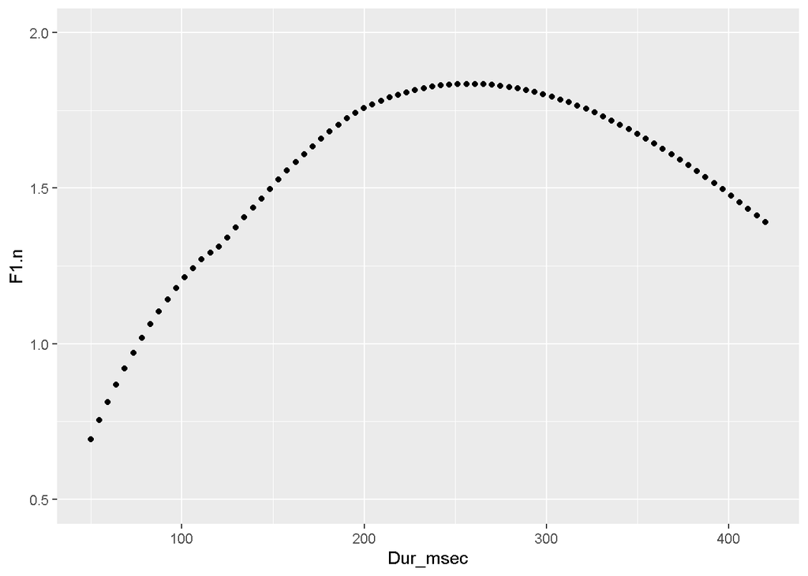

```r
ggplot(I_jean, aes(Dur_msec, F1.n)) +
  stat_smooth(geom = "point")
```

Or point ranges.

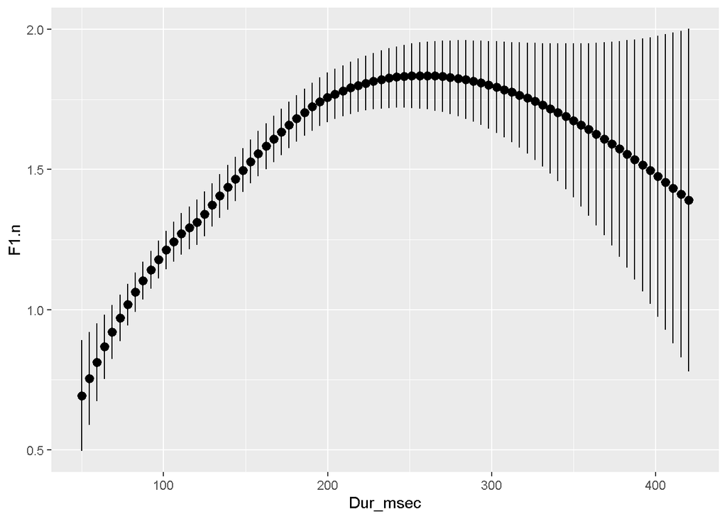

```r
ggplot(I_jean, aes(Dur_msec, F1.n)) +
  stat_smooth(geom = "pointrange")
```

Coming from the other direction, you can specify special statistics for geometries.

```r
ggplot(I_jean, aes(Dur_msec, F1.n)) +
  geom_point()
```

[output not shown]

[figure not shown]

```r
ggplot(I_jean, aes(Dur_msec, F1.n)) +
  geom_point(stat = "smooth")
```

They key point here is: Every geometry displays a statistic, even if that’s just the identity statistic. All geometries have a default statistic, which can be overrode. All statistics are displayed with a geometry. All statistics have a default geometry, which can be overrode.

This intimate interrelationship between statistics and geoms is why there are so many statistics and geoms with the same name.

```r
geoms <- gsub("geom_", "", apropos("^geom_"))
stats <- gsub("stat_", "", apropos("^stat_"))

stats[stats %in% geoms]
```

```
##  [1] "bin2d"      "boxplot"    "contour"    "count"      "density"
##  [6] "density_2d" "density2d"  "qq"         "qq_line"    "quantile"
## [11] "sf"         "smooth"     "spoke"
```

### Particularly useful Statistics

#### stat_smooth()

The most common statistic to add to a plot is stat_smooth(). The default behavior for stat_smooth() is sensitive to how many data points there are in a plot. The plot below contains < 1000 points, meaning that its plotting a loess smooth. For points > 1000, it’ll fit a generalized additive model with penalized cubic regression splines.

```r
ggplot(I_jean, aes(Dur_msec, F1.n)) +
  stat_smooth()
```

[output not shown]

We can change the method of smoothing manually by specifying a regression function. Any regression method which

1. utilizes the formula specification, and
2. has a predict() method

can be used with stat_smooth(). For example, we could plot an ordinary linear regression by saying method = lm.

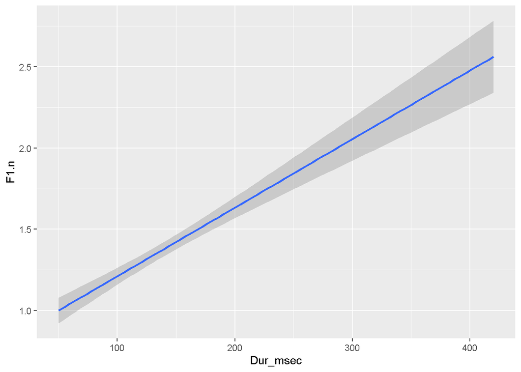

```r
ggplot(I_jean, aes(Dur_msec, F1.n)) +
  stat_smooth(method = lm)
```

Any and all arguments that you might pass to lm() can be passed to stat_smooth(), including formula. So, for instance, if we wanted to fit a third-order polynomial curve to the data using lm, we would do so like this.

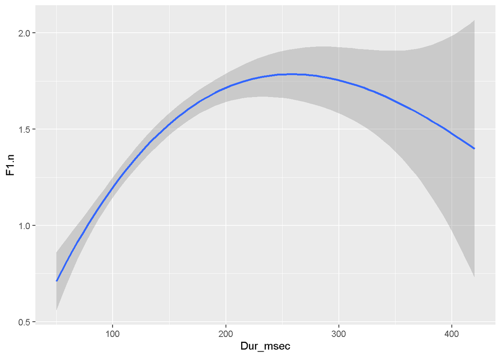

```r
ggplot(I_jean, aes(Dur_msec, F1.n)) +
  stat_smooth(method = lm, formula = y ~ poly(x, 3))
```

Here’s how to fit b-splines with a relatively large basis for the amount of data.

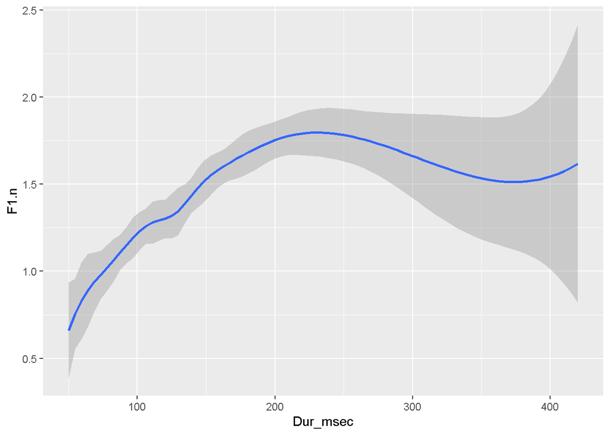

```r
library(splines)
ggplot(I_jean, aes(Dur_msec, F1.n)) +
  stat_smooth(method = lm, formula = y ~ bs(x, df = 10))
```

And a generalized additive model fit with a cubic regression spline.

```r
library(mgcv)
```

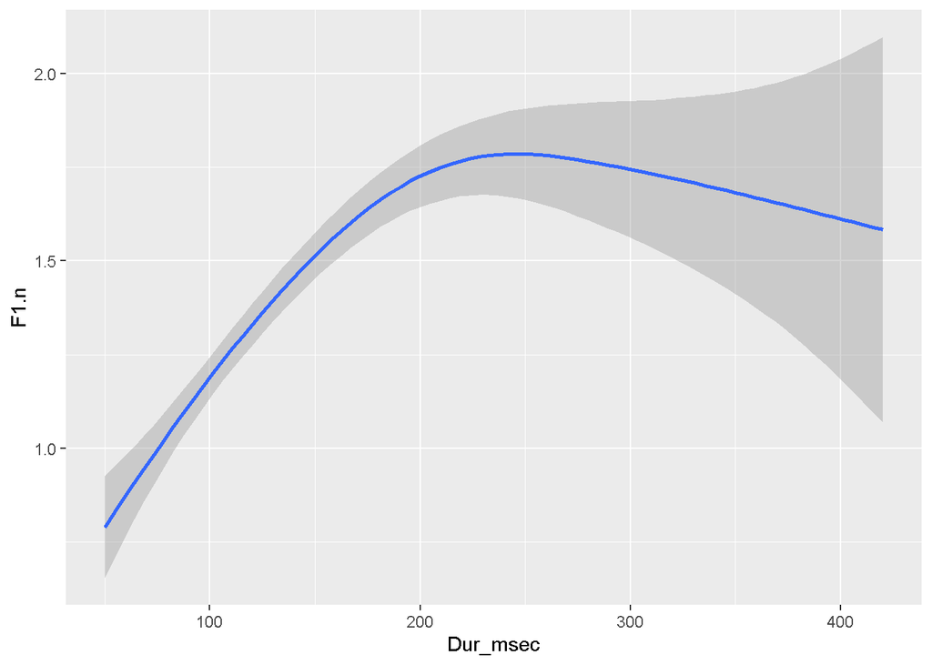

```r
ggplot(I_jean, aes(Dur_msec, F1.n)) +
  stat_smooth(method = gam, formula = y ~ s(x, bs = "cs"))
```

You can also include regression lines for other kinds of response variables. For example, let’s create a binomial variable based on whether or not F1 is greater than the median F1.

```r
I_jean$F1_median <- (I_jean$F1.n > median(I_jean$F1.n)) * 1
head(I_jean)
```

```
##    Name Age Sex Word FolSegTrans Dur_msec     F1     F2      F1.n       F2.n
## 1 Jean   61   f  I'M           M      130  861.7 1335.8 1.6608625 -0.8855366
## 2 Jean   61   f    I           N      140 1010.4 1349.3 2.6882695 -0.8536494
## 3 Jean   61   f I'LL           L      110  670.1 1292.7 0.3370482 -0.9873394
## 4 Jean   61   f  I'M           M      180  869.8 1307.0 1.7168275 -0.9535626
## 5 Jean   61   f    I           R       80  743.0 1418.7 0.8407333 -0.6897257
## 6 Jean   61   f I'VE           V      120  918.2 1580.8 2.0512357 -0.3068434
##   F1_median
## 1         1
## 2         1
## 3         0
## 4         1
## 5         0
## 6         1
```

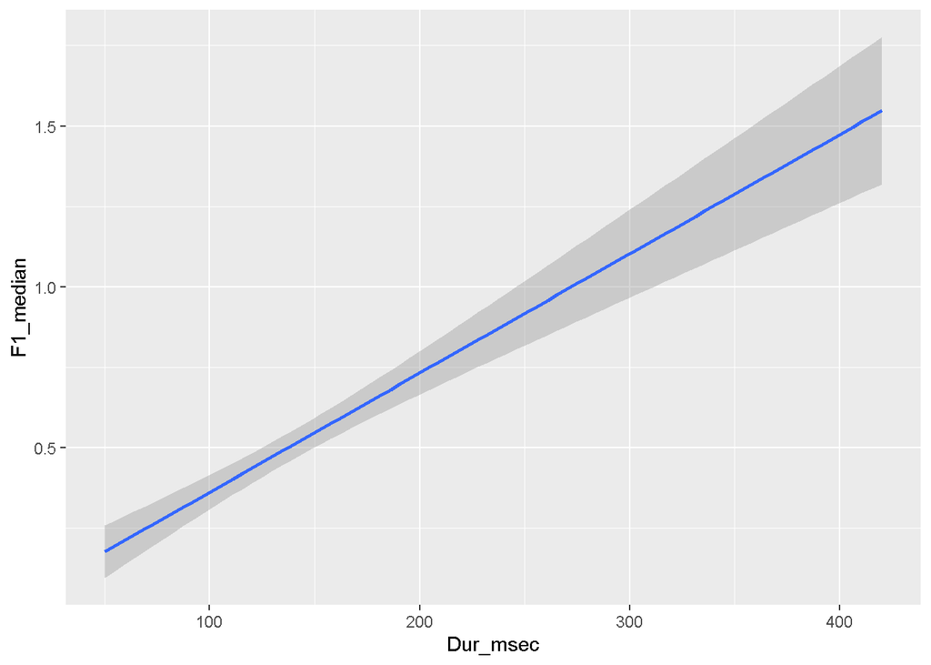

```r
ggplot(I_jean, aes(Dur_msec, F1_median))+
  stat_smooth(method = glm, family = binomial)
```

And just like we did for the continuous F1 variable, we can adjust the model formula for more complex regressions.

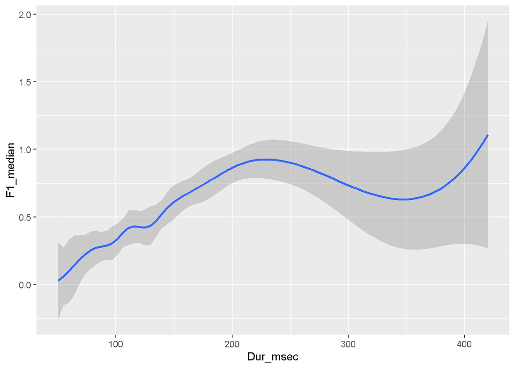

```r
## b-splines
ggplot(I_jean, aes(Dur_msec, F1_median))+
  stat_smooth(method = glm,
              family = binomial,
              formula  = y ~ bs(x, df = 10))
```

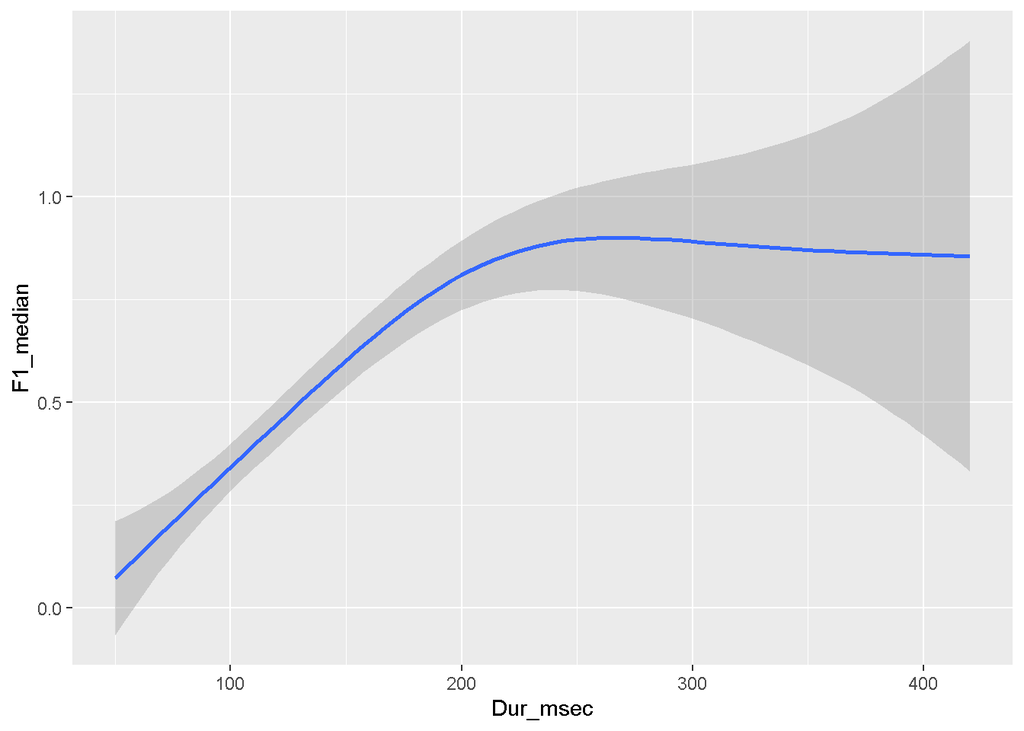

```r
## cubic regression splines
ggplot(I_jean, aes(Dur_msec, F1_median))+
  stat_smooth(method = gam,
              family = binomial,
              formula  = y ~ s(x, bs = "cs"))
```

#### stat_summary()

Another very useful statistic is stat_summary(), which allows you to plot arbitrary summaries of your data. stat_summary() takes all of the data along the y-axis for each value along the x-axis, applies the summary function that you pass to fun.y, then plots that value with the specified geom. For example, we may want to plot each lexical item and its mean duration, represented by a bar.

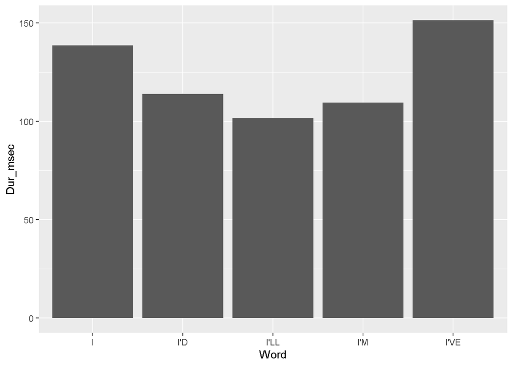

```r
ggplot(I_jean, aes(Word, Dur_msec))+
  stat_summary(fun.y = mean, geom = "bar")
```

You can experiment with different summary functions and geometries as you desire.

Along with defining fun.y, you can also define fun.data, which allows you to plot ranges of data summaries with errorbars, or other similar geometries. There are 4 nicely tuned functions in ggplot2 for doing this.

- mean_cl_boot() - This will return the sample mean, and 95% bootstrap confidence intervals.
- mean_cl_normal() - This will return the sample mean, and the 95% percent Gaussian confidence interval based on the -distribution
- mean_sdl() - This will return the sample mean and values at 1 sd and -1 sd away. You can make it return points any arbitrary number of sds away by passing that value to mult. For example, mult = 2 will return 2 and -2 sds.
- median_hilow() - This will return the sample median, and confidence intervals running from the 0.025 quantile to the 0.975 quantile, which covers 95% of the range of the data. You can change what range of the data you want the confidence interval to cover by passing it to conf.int. For example conf.int = 0.5 will return confidence intervals ranging from the 0.25 quantile to the 0.75 quantile.

Coming back to the example of plotting the mean durations for each word, all we need to do is add another stat_summary() layer. For ordinary error bars, we’ll use geom_errorbar().

[figure not shown]

```r
ggplot(I_jean, aes(Word, Dur_msec))+
  stat_summary(fun.y = mean, geom = "bar", fill = "grey40")+
  stat_summary(fun.data = mean_cl_normal, geom = "errorbar")
```

But I think that error bars are pretty ugly in comparison to point ranges, and it’s always worth going for bootstrapped estimates since they have fewer assumptions.

[figure not shown]

```r
ggplot(I_jean, aes(Word, Dur_msec))+
  stat_summary(fun.y = mean, geom = "bar", fill = "grey40")+
  stat_summary(fun.data = mean_cl_boot, geom = "pointrange")
```

### Values created by statistics

Statistical layers added to plots actually create new pieces of data, like the y-coordinates of the smoother. Some statistical layers create a few different values, and you can choose which one you want to plot. For example, here is a density plot, where the kernel density estimate is represented by a colored line.

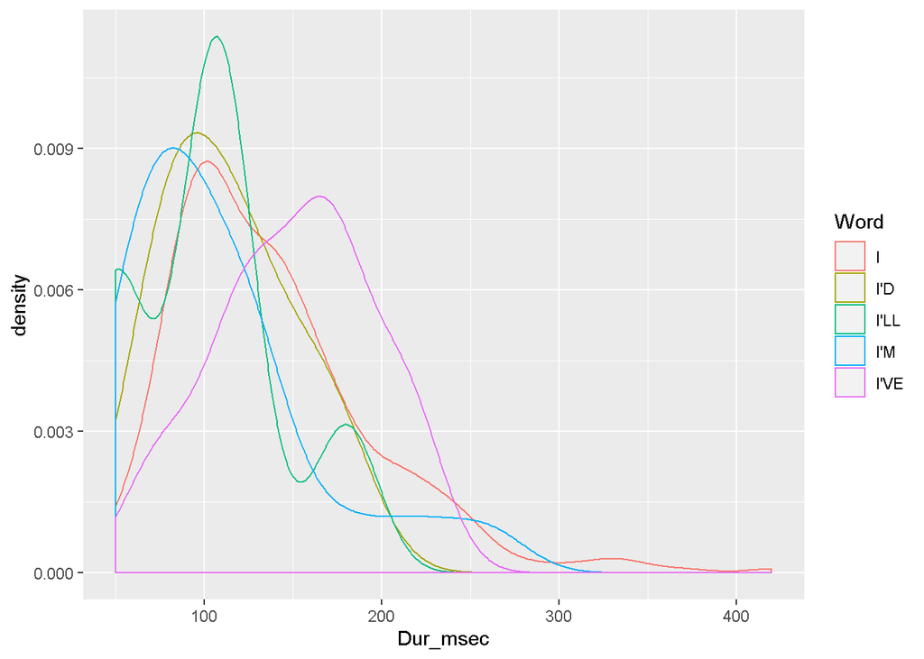

```r
ggplot(I_jean, aes(Dur_msec, color = Word))+
  geom_density()
```

You have to understand the densities represented in this plot as being conditional on selecting a specific word. That is, given that we have decided to think about the lexical item “I’ve”, what is the probability it will be found in a specific range of durations?

However, it’s also possible to plot densities that are not conditional lexical item. That is, given a range of durations, what is the mixture of lexical items we’ll find there? We can do this by plotting a value called ..count.. along the y-axis. ..count.. is created by stat_density(), which is why it’s begins and ends with … All values that are created by a statistical layer begin and end with … Here’s the result of plotting ..count.. along the y-axis.

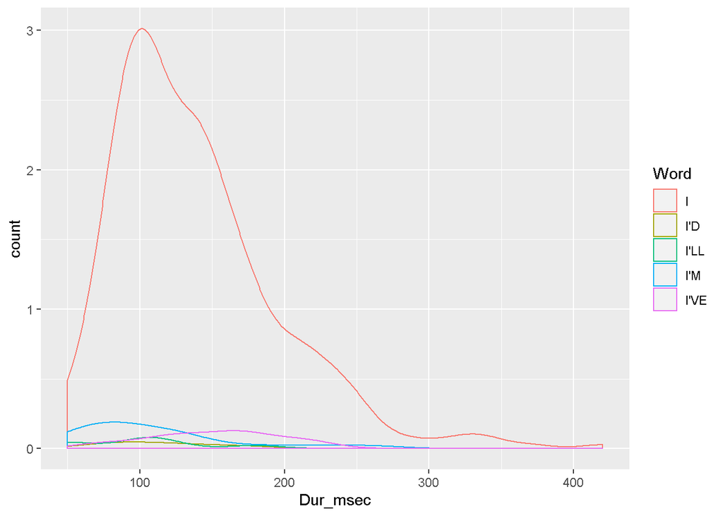

```r
ggplot(I_jean, aes(Dur_msec, color = Word))+
  geom_density(aes(y = ..count..))
```

The density distribution for “I” is suddenly huge, and that’s because it’s so frequent. Note that I used y = ..count.. for stacking and filling density distributions above, because that’s actually the only thing that makes any sense. Compare the following two filled density plots.

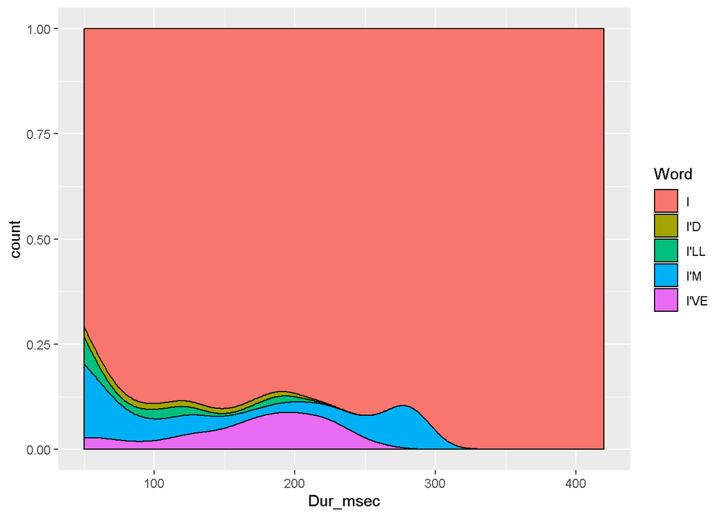

```r
ggplot(I_jean, aes(Dur_msec, fill = Word))+
  geom_density(aes(y = ..count..), position = "fill")
```

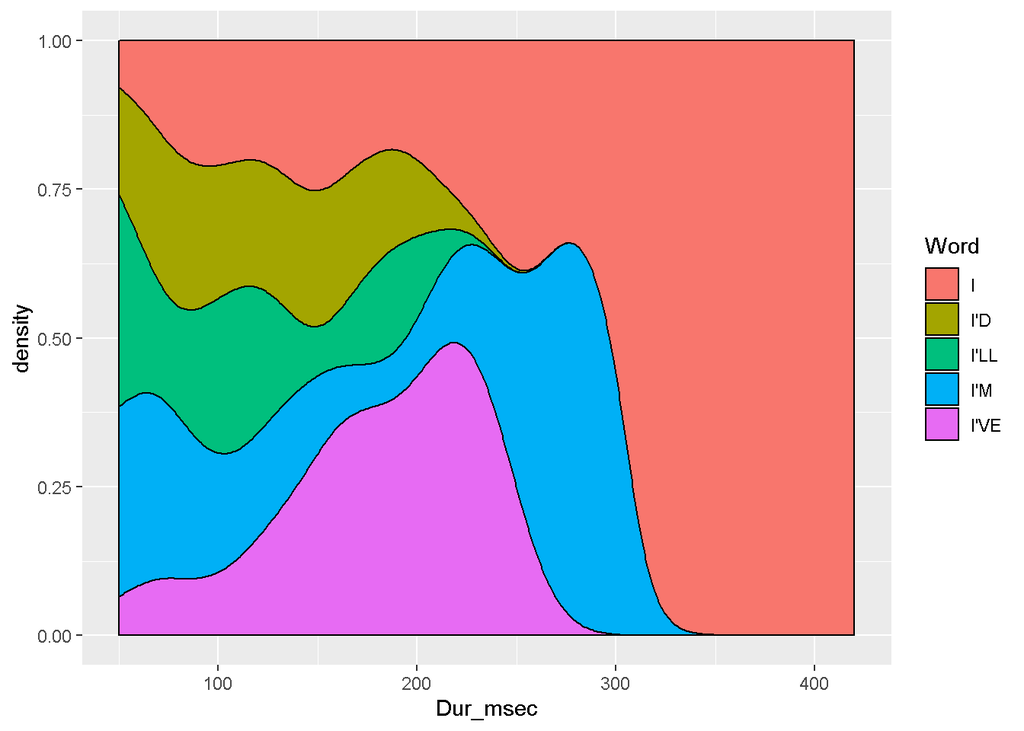

```r
ggplot(I_jean, aes(Dur_msec, fill = Word))+
  geom_density(aes(y = ..density..), position = "fill")
```

We know that “I” is super frequent, so the plot with y = ..count.. is the accurate one. What the plot with y = ..density.. is actually displaying is a little complicated to worry about, and it would almost certainly confuse any readers of your papers.

Another cool use of values generated by a statistic is with two dimensional density estimation. Here’s an F2 by F1 plot, illustrating the default behavior of stat_density2d().

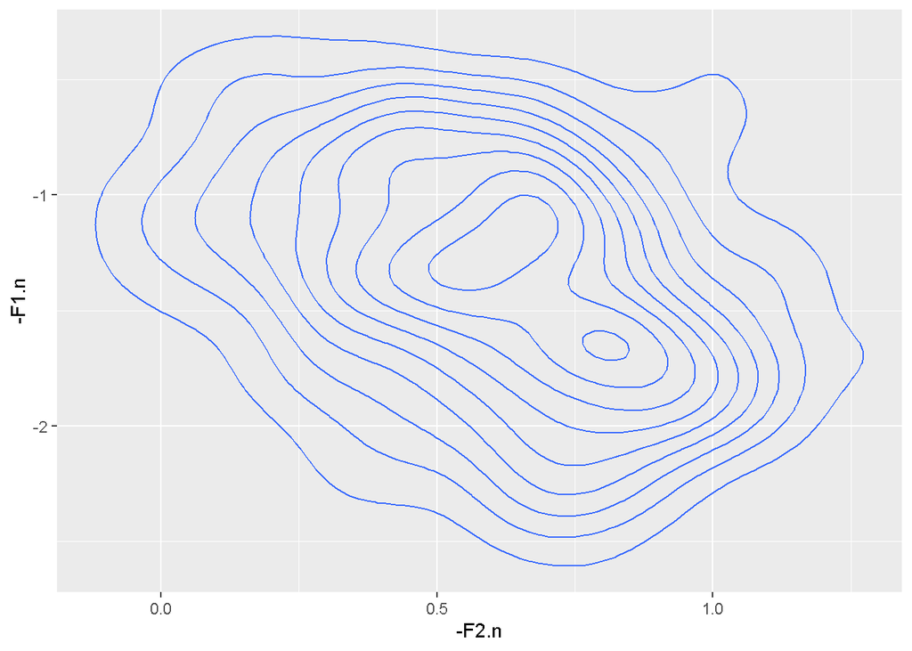

```r
ggplot(I_jean, aes(-F2.n, -F1.n))+
  stat_density2d()
```

The default behavior of stat_density2d() is to bin up the two dimensional density estimates into discrete levels for plotting as topographic contours. The value corresponding to this discretized density estimate is called ..level.., and we can use it to replace the contour lines with filled in polygons.

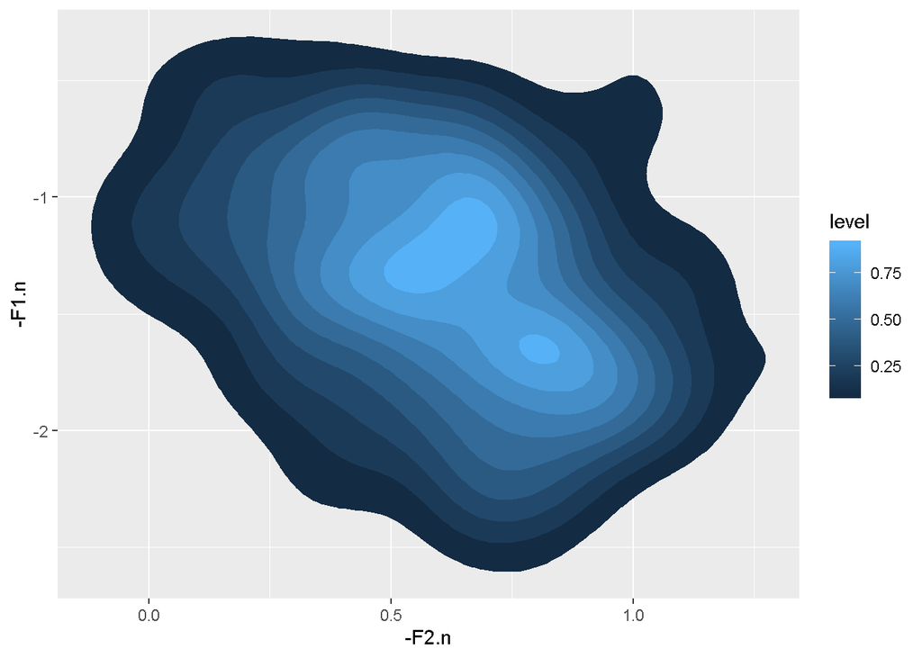

```r
ggplot(I_jean, aes(-F2.n, -F1.n))+
  stat_density2d(geom = "polygon", aes(fill = ..level..))
```

Or, we can turn off the discritization entirely by saying contour = F, and then access the density estimate itself, ..density.. and map that to a variety of different aesthetics.

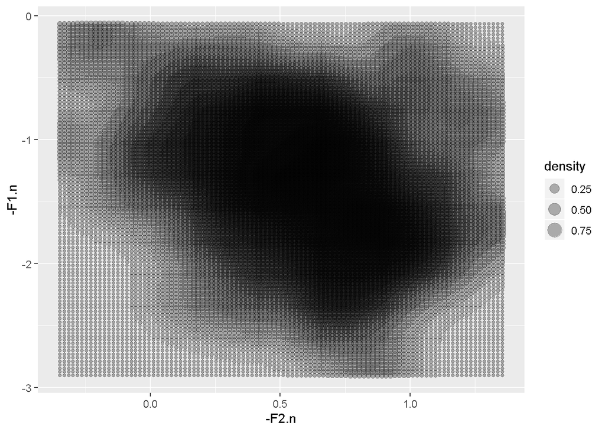

```r
ggplot(I_jean, aes(-F2.n, -F1.n))+
  stat_density2d(geom = "point",contour = F,
                 aes(size = ..density..), alpha = 0.3)
```

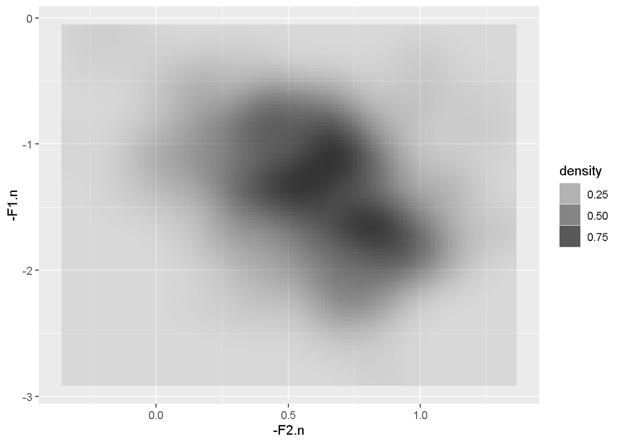

```r
ggplot(I_jean, aes(-F2.n, -F1.n))+
  stat_density2d(geom = "tile", contour = F, aes(alpha = ..density..))
```

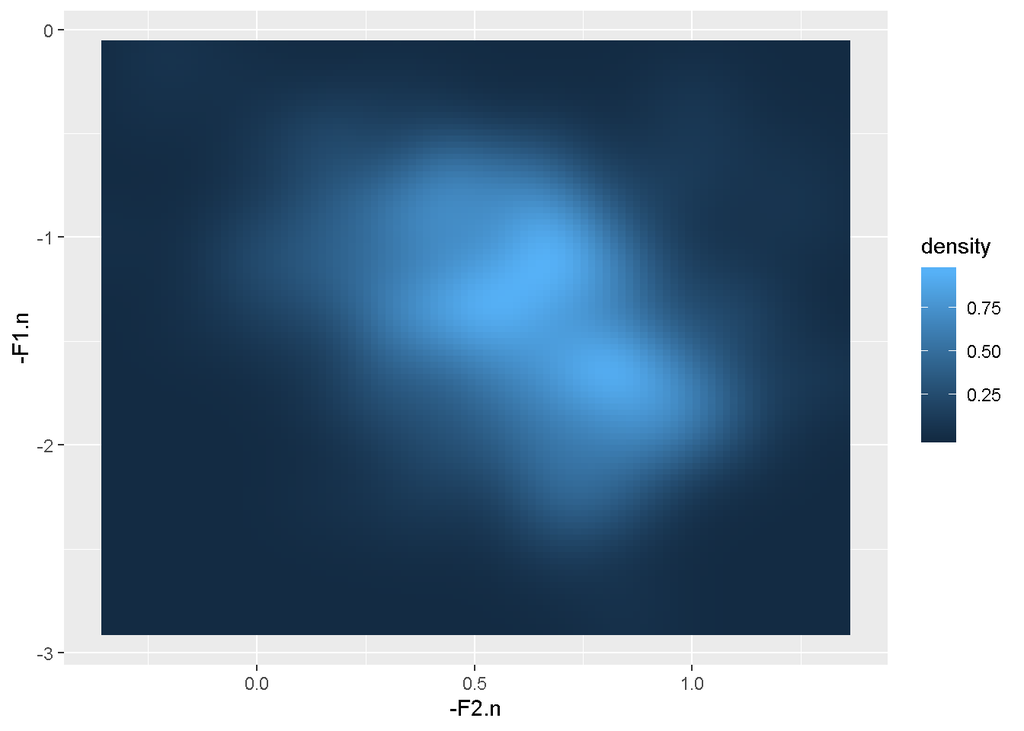

```r
ggplot(I_jean, aes(-F2.n, -F1.n))+
  stat_density2d(geom = "tile", contour = F, aes(fill = ..density..))
```

## Scales

Scales provide you more fine grained control over over the presentation of aesthetics. For every aesthetic, there is a corresponding scale you can use.

### x and y scales

All scales begin with scale_ followed by the name of the aesthetic it controls, then followed by its sub-type. Here are all the x-axis scales, for which there are identical y-axis scales.

```r
apropos("^scale_x_")
```

```
## [1] "scale_x_continuous" "scale_x_date"       "scale_x_datetime"
## [4] "scale_x_discrete"   "scale_x_log10"      "scale_x_reverse"
## [7] "scale_x_sqrt"       "scale_x_time"
```

scale_x_continuous, scale_x_discrete, scale_x_datetime and scale_x_date are the basic kinds of x and y axes you can construct in ggplot2. For the most part, ggplot2 will figure out which kind of scale to use, and you’ll only need to add one of these if you want to modify the default appearance.

scale_x_log10, scale_x_sqrt and scale_x_reverse are basic transformations to a continuous scale. Many more kinds of transformations are possible, and it’s even possible to define your own custom transformations, but these are the only ones for which there are special convenience scale_x_* functions.

### scale_ arguments

There are a few basic arguments that you can pass to a scale.

- name - This is the title that will be displayed on the scale, either on the axes for x and y scales, or in the legend for other scales.
- limits - This defines the range of data to be presented in the plot. For discrete scales, it’ll define the order with which to display categorical factors.
- breaks - These are the labeled points along the scale, either the major axis labels, or the labels on the legend.
- labels - This defines the labels to use at each break point, if you want to override them
- trans - This defines a numerical transformation you’d like to apply to a scale, and usually only applicable to continuous scales. We’ll talk more about transformations below.

#### scale_[xy]_continuous

Here’s our basic duration by F1 plot again, which has two continuous scales for the x and y axes.

```r
ggplot(I_jean, aes(Dur_msec, F1.n))+
  geom_point()
```

[output not shown]

If we want to change the x axis label, we can do so by adding scale_x_continious() and passing our desired title to name.

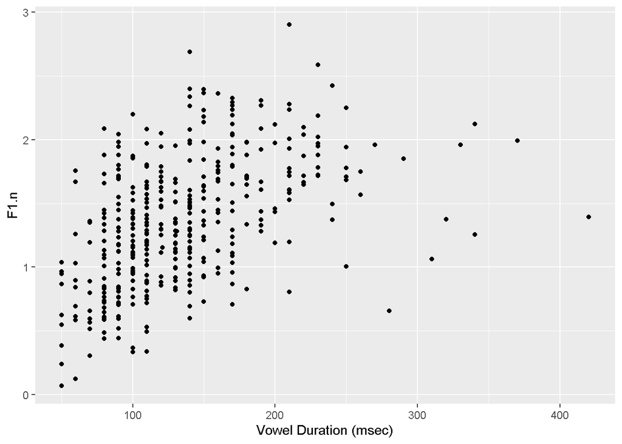

```r
ggplot(I_jean, aes(Dur_msec, F1.n))+
  geom_point()+
  scale_x_continuous(name = "Vowel Duration (msec)")
```

Since changing the axis titles is something you’re likely to do very frequently, there are two convenience functions for this purpose with shorter names that save you typing: xlab() and ylab().

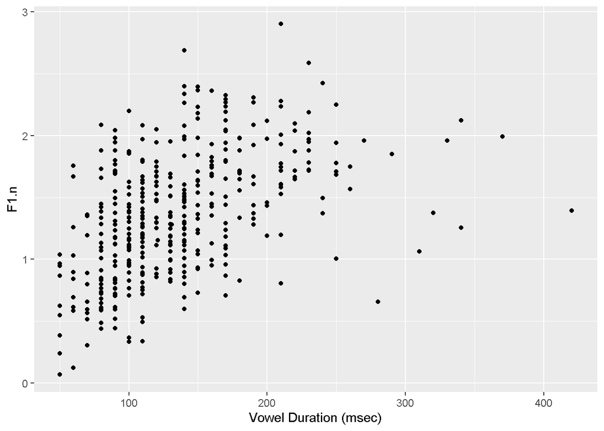

```r
ggplot(I_jean, aes(Dur_msec, F1.n))+
  geom_point()+
  xlab("Vowel Duration (msec)")
```

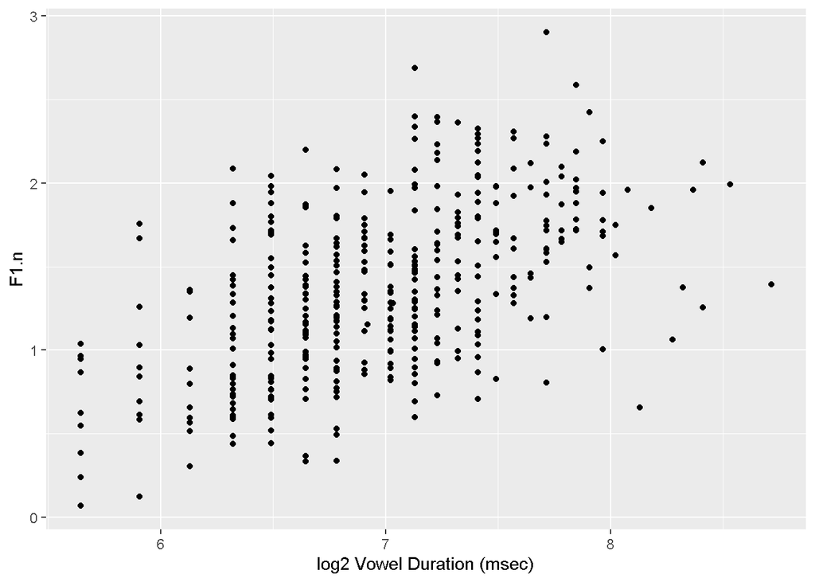

```r
ggplot(I_jean, aes(log2(Dur_msec), F1.n))+
  geom_point()+
  scale_x_continuous("log2 Vowel Duration (msec)")
```

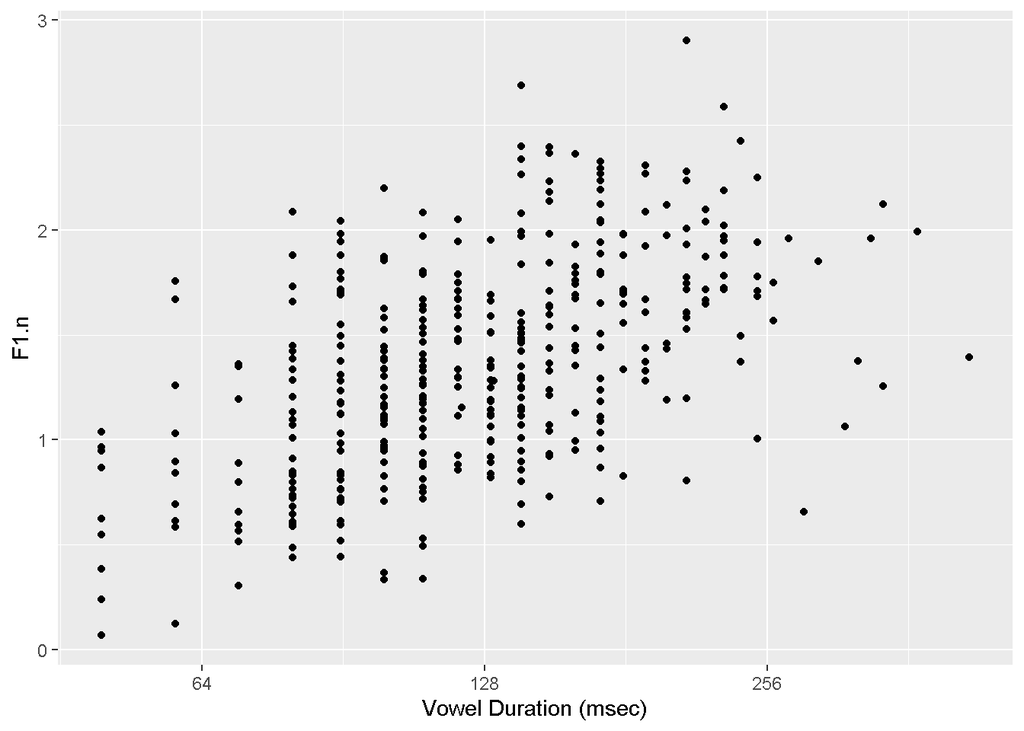

```r
ggplot(I_jean, aes(Dur_msec, F1.n))+
  geom_point()+
  scale_x_continuous("Vowel Duration (msec)",
                     trans = "log2")
```

```r
apropos("_trans")
```

```
## [1] "coord_trans"
```

And here are some in action.

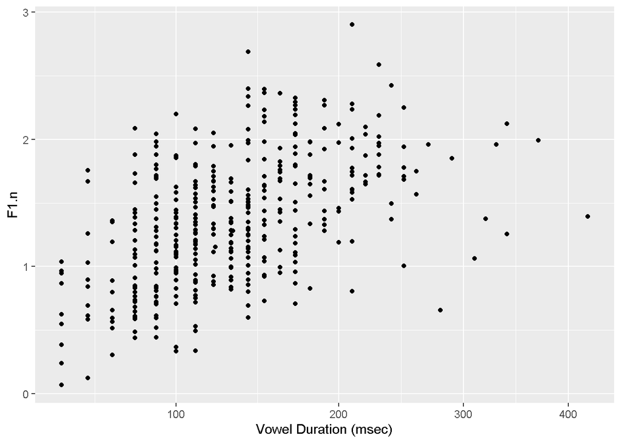

```r
ggplot(I_jean, aes(Dur_msec, F1.n))+
  geom_point()+
  scale_x_continuous("Vowel Duration (msec)",
                     trans = "sqrt")
```

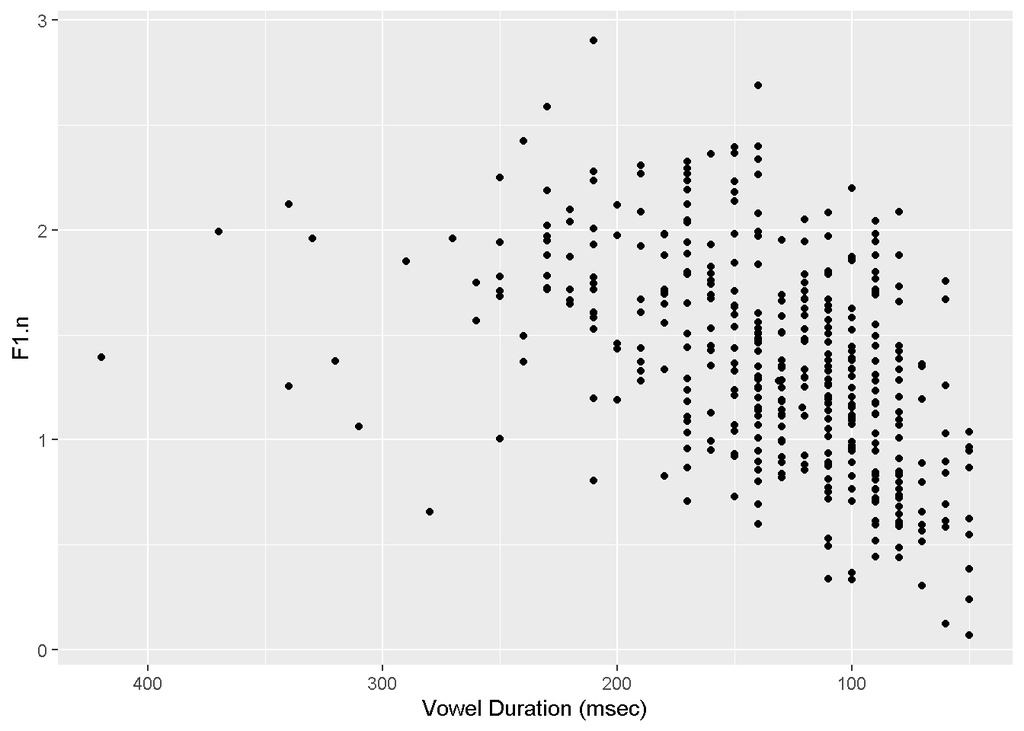

```r
ggplot(I_jean, aes(Dur_msec, F1.n))+
  geom_point()+
  scale_x_continuous("Vowel Duration (msec)",
                     trans = "reverse")
```

One frustrating thing is that it’s not possible to apply two transformations to a scale at once. For example, I frequently want to both log transform an axis and reverse it. It’s possible, though, to define a new transformation with the scales package, but for that I’ll refer you to the ggplot 0.9.0 transition guide.

### color and fill scales

Here are all of the color scales, for all of which there is an accompanying fill scale.

```r
apropos("^scale_color_")
```

```
##  [1] "scale_color_brewer"     "scale_color_continuous" "scale_color_discrete"
##  [4] "scale_color_distiller"  "scale_color_gradient"   "scale_color_gradient2"
##  [7] "scale_color_gradientn"  "scale_color_grey"       "scale_color_hue"
## [10] "scale_color_identity"   "scale_color_manual"     "scale_color_viridis_c"
## [13] "scale_color_viridis_d"
```

There are two very distinct kinds of color scales here: categorical and gradient. The use of one over the other has everything to do with the kind of data which is passed to color and fill, and they have their own specific customizations.

#### Categorical color scales

Here is the default categorical color scale, which is called scale_[fill/color]_hue()

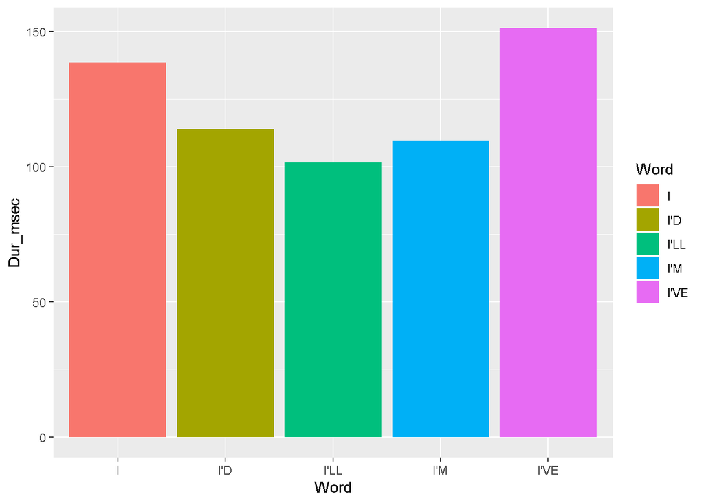

```r
ggplot(I_jean, aes(Word, Dur_msec, fill = Word))+
  stat_summary(fun.y = mean, geom = "bar")+
  scale_fill_hue()
```

Just like the x and y scales, you can change the title, limits, breaks and labels of this scale, which will control how it appears in the legend. Here’s an illustrative example, which actually detracts from the default

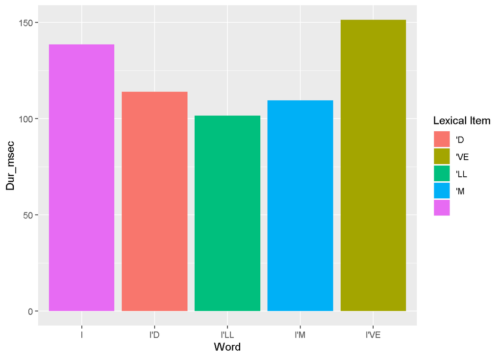

```r
ggplot(I_jean, aes(Word, Dur_msec, fill = Word))+
  stat_summary(fun.y = mean, geom = "bar")+
  scale_fill_hue(name = "Lexical Item",
                 limits = c("I'D","I'VE","I'LL","I'M","I"),
                 labels = c("'D","'VE","'LL","'M",""))
```

Many people don’t like the default color scheme, but there are other available color palettes, and you can define your own. One really nice set of color palettes comes from the package RColorBrewer. You can explore the set of available color palettes available in it here. A personal favorite of mine is called Set1, which you can apply to the plot with scale_fill_brewer()

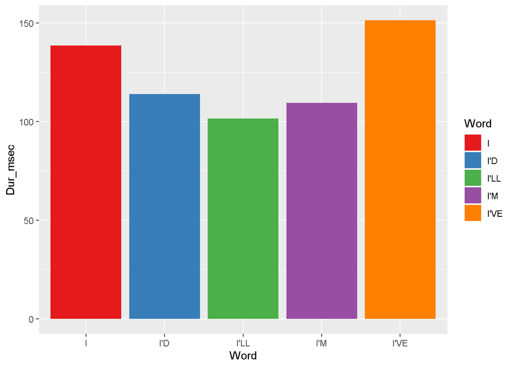

```r
ggplot(I_jean, aes(Word, Dur_msec, fill = Word))+
  stat_summary(fun.y = mean, geom = "bar")+
  scale_fill_brewer(palette = "Set1")
```

If you are particularly picky, or want to express your questionable aesthetic sense to the world, there is also scale_fill_manual(), where you define an arbitrary list of colors to use for the scale.

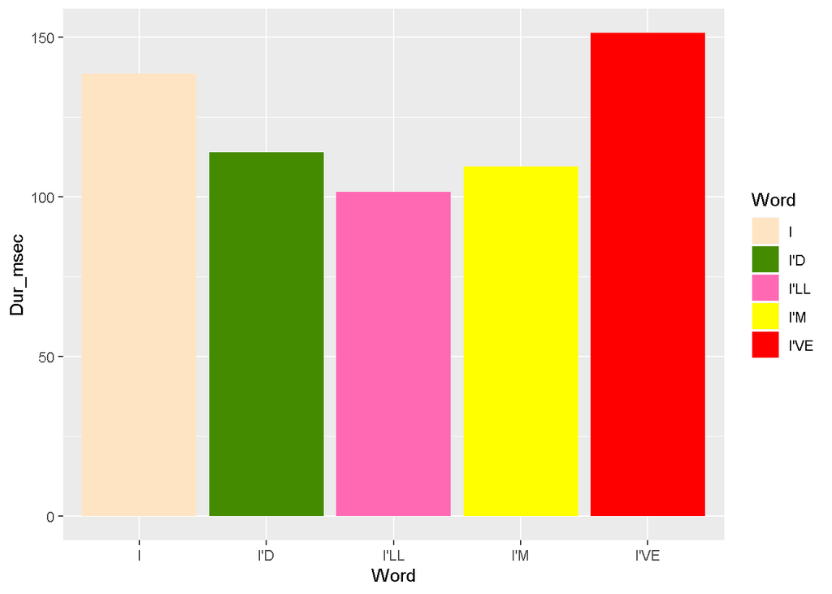

```r
ggplot(I_jean, aes(Word, Dur_msec, fill = Word))+
  stat_summary(fun.y = mean, geom = "bar")+
  scale_fill_manual(values=c("bisque", "chartreuse4",
                             "hotpink","yellow", "red"))
```

And finally, if you’re preparing a plot for publication, and you want to be sure that the colors will be distinguishable when printed in black and white, there is scale_fill_grey().

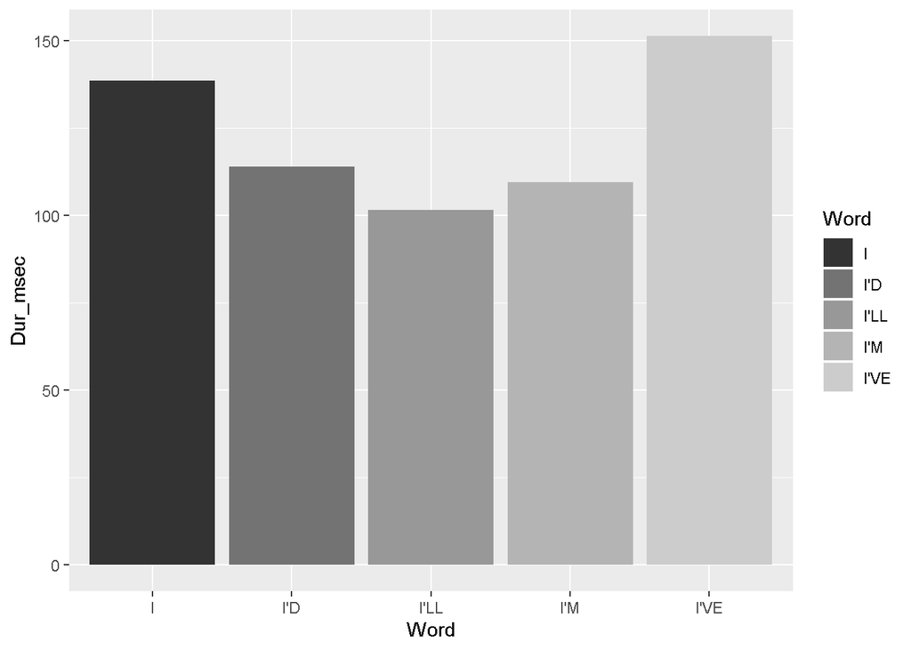

```r
ggplot(I_jean, aes(Word, Dur_msec, fill = Word))+
  stat_summary(fun.y = mean, geom = "bar")+
  scale_fill_grey()
```

#### Gradient color scales

There are also a nice set of customizable gradient color scales. Here’s the default gradient color scale, which is called scale_fill_gradient()

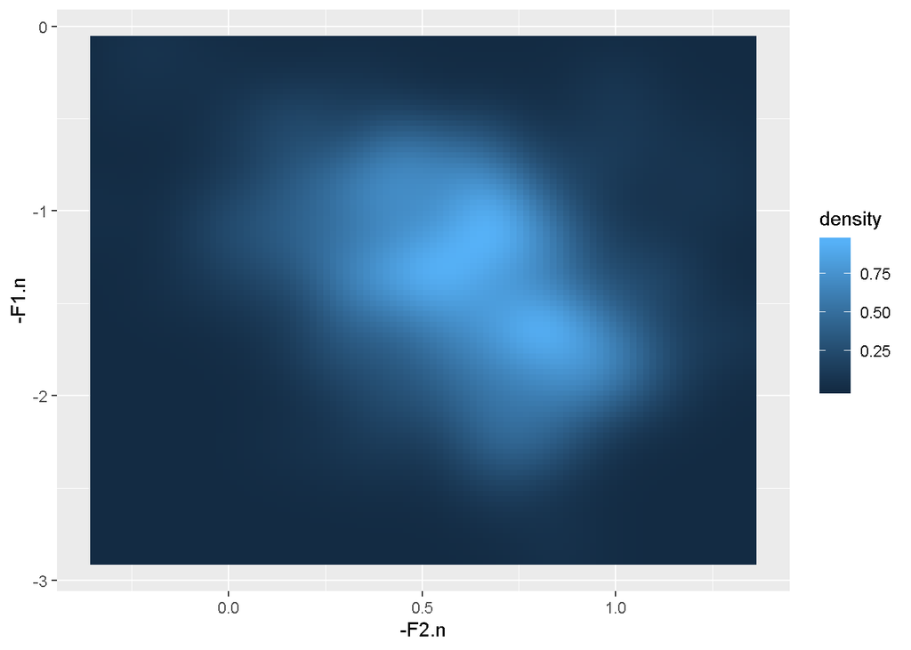

```r
ggplot(I_jean, aes(-F2.n, -F1.n))+
  stat_density2d(geom = "tile",contour = F, aes(fill = ..density..))+
  scale_fill_gradient()
```

scale_fill_gradient() constructs a color continuum from A to B, where the lowest values in the plot will have solid A, and the highest values in the plot will have solid B, and everything else will fall along the gradient. It’s possible to override the original two colors that the gradient is built between by passing the colors you prefer to low and high.

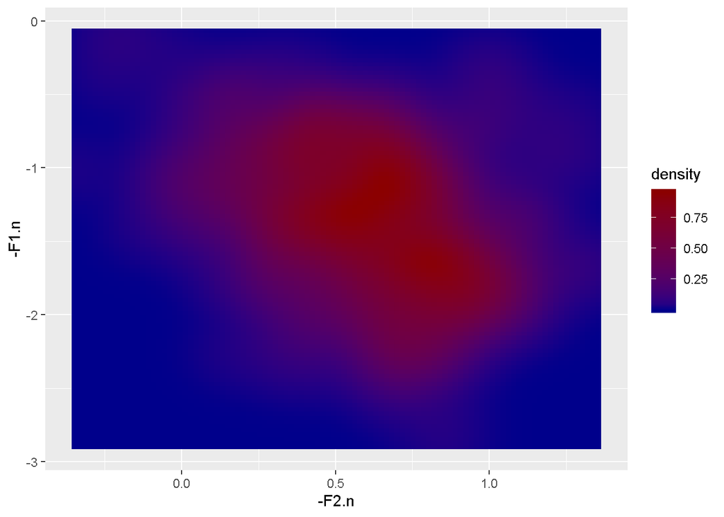

```r
ggplot(I_jean, aes(-F2.n, -F1.n))+
  stat_density2d(geom = "tile",contour = F, aes(fill = ..density..))+
  scale_fill_gradient(low="darkblue",high="darkred")
```

It’s also possible to define a gradient that passes from A to B via C with scale_fill_gradient2(). Here, you define low and high, as well as a third color you want the gradient to transition through, mid. You also need to define the value the scale should treat as a midpoint.

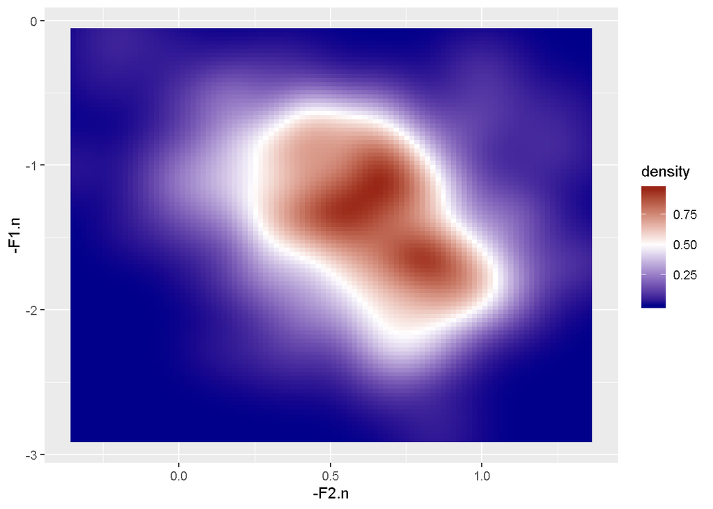

```r
ggplot(I_jean, aes(-F2.n, -F1.n))+
  stat_density2d(geom = "tile",contour = F, aes(fill = ..density..))+
  scale_fill_gradient2(low="darkblue",
                       high="darkred",
                       mid="white",
                       midpoint=0.5)
```

And, finally, you’re able to define a color gradient passing through any arbitrary colors with scale_fill_gradientn(). Here’s a pretty ugly one:

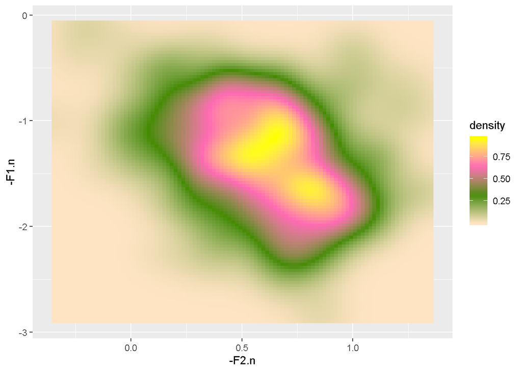

```r
ggplot(I_jean, aes(-F2.n, -F1.n))+
  stat_density2d(geom = "tile",contour = F, aes(fill = ..density..))+
  scale_fill_gradientn(colours = c("bisque", "chartreuse4",
                                    "hotpink","yellow"))
```

A benefit to having scale_fill_gradientn() is that you can utilize some of R’s built in color palettes, like rainbow(), terrain.colors() and topo.colors()

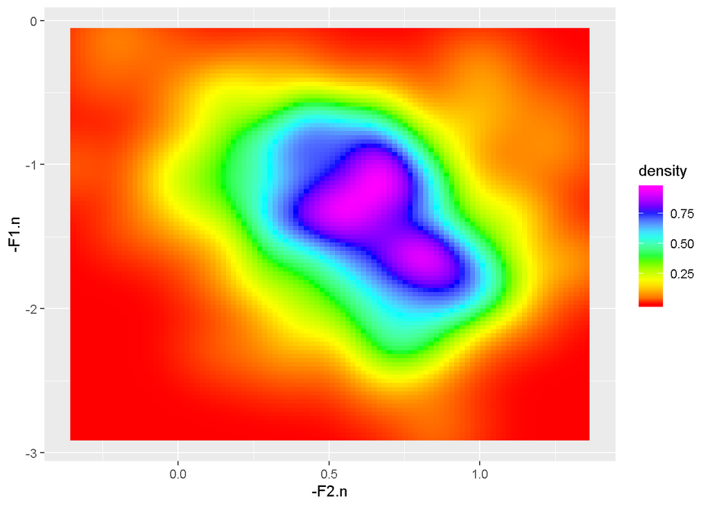

```r
ggplot(I_jean, aes(-F2.n, -F1.n))+
  stat_density2d(geom = "tile",contour = F, aes(fill = ..density..))+
  scale_fill_gradientn(colours = rainbow(6))
```

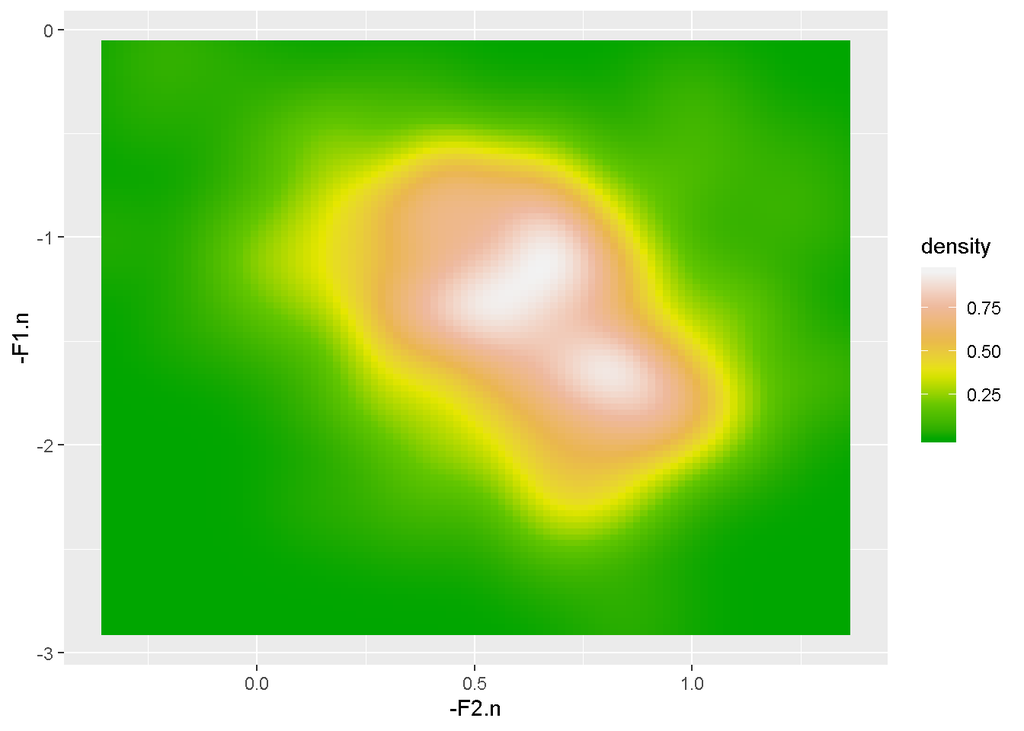

```r
ggplot(I_jean, aes(-F2.n, -F1.n))+
  stat_density2d(geom = "tile",contour = F, aes(fill = ..density..))+
  scale_fill_gradientn(colours = terrain.colors(6))
```

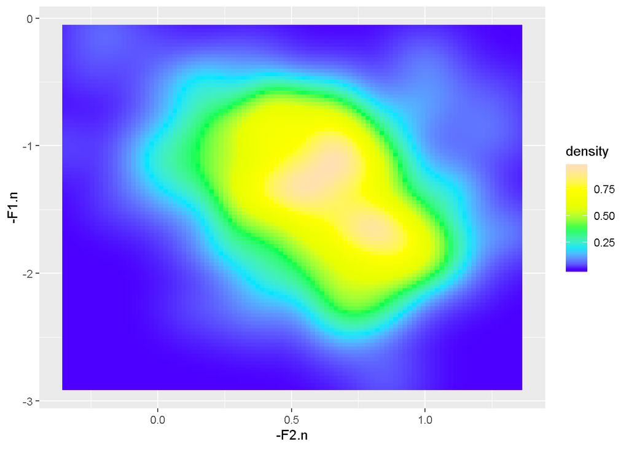

```r
ggplot(I_jean, aes(-F2.n, -F1.n))+
  stat_density2d(geom = "tile",contour = F, aes(fill = ..density..))+
  scale_fill_gradientn(colours = topo.colors(6))
```

#### Guides

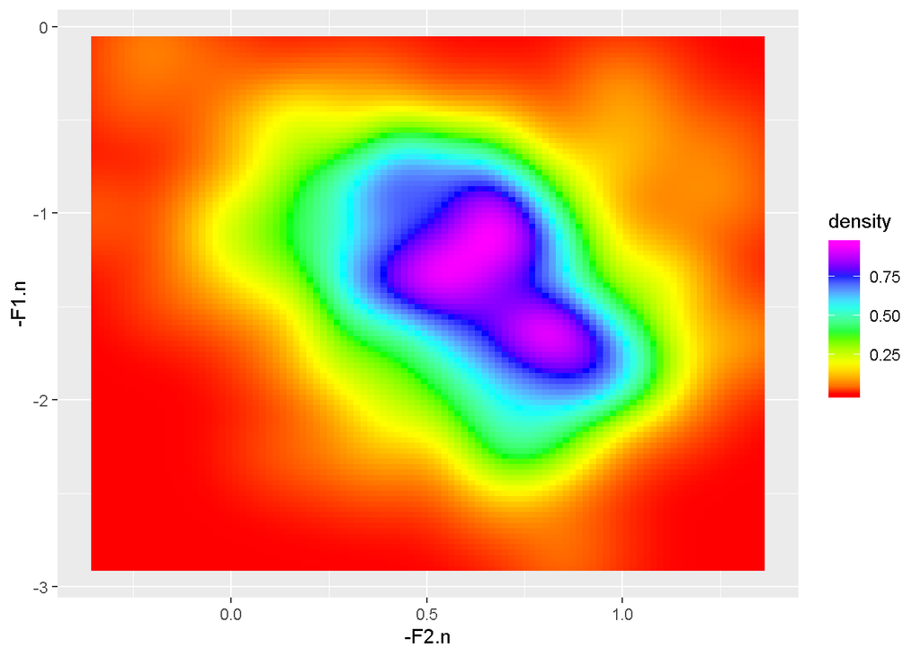

```r
ggplot(I_jean, aes(-F2.n, -F1.n))+
  stat_density2d(geom = "tile",contour = F, aes(fill = ..density..))+
  scale_fill_gradientn(colours = rainbow(6),
                       guide = "colorbar")
```

### shape and linetype

The shape and linetype scales are much more limited. Despite the apparent existence of scale_shape_continuous and scale_linetype_continuous, you can’t actually pass continuous variable to these aesthetics.

```r
apropos("^scale_shape_")
```

```
## [1] "scale_shape_continuous" "scale_shape_discrete"   "scale_shape_identity"
## [4] "scale_shape_manual"     "scale_shape_ordinal"
```

```r
apropos("^scale_linetype_")
```

```
## [1] "scale_linetype_continuous" "scale_linetype_discrete"
## [3] "scale_linetype_identity"   "scale_linetype_manual"
```

The only time you’ll be likely to use the shape and linetype scales is when you want to manually control the point shape and linetypes to be used. I actually find the default shape scale to not be strongly contrastive, and prefer to contrast point types based on filled vs hollow shapes.

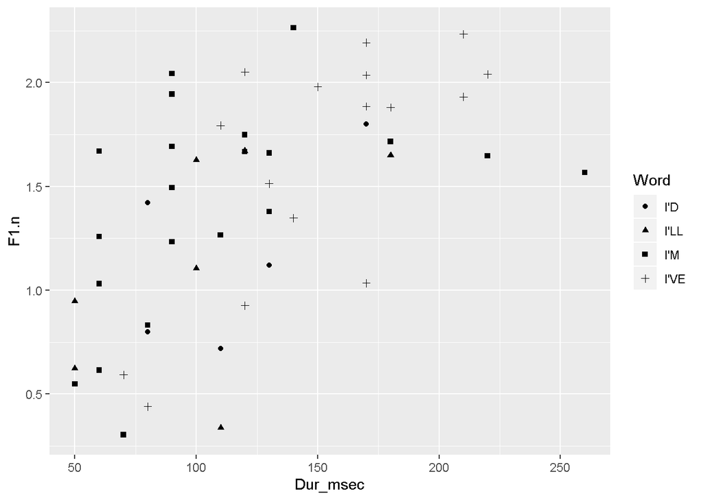

```r
ggplot(I_subset, aes(Dur_msec, F1.n, shape = Word))+
  geom_point()
```

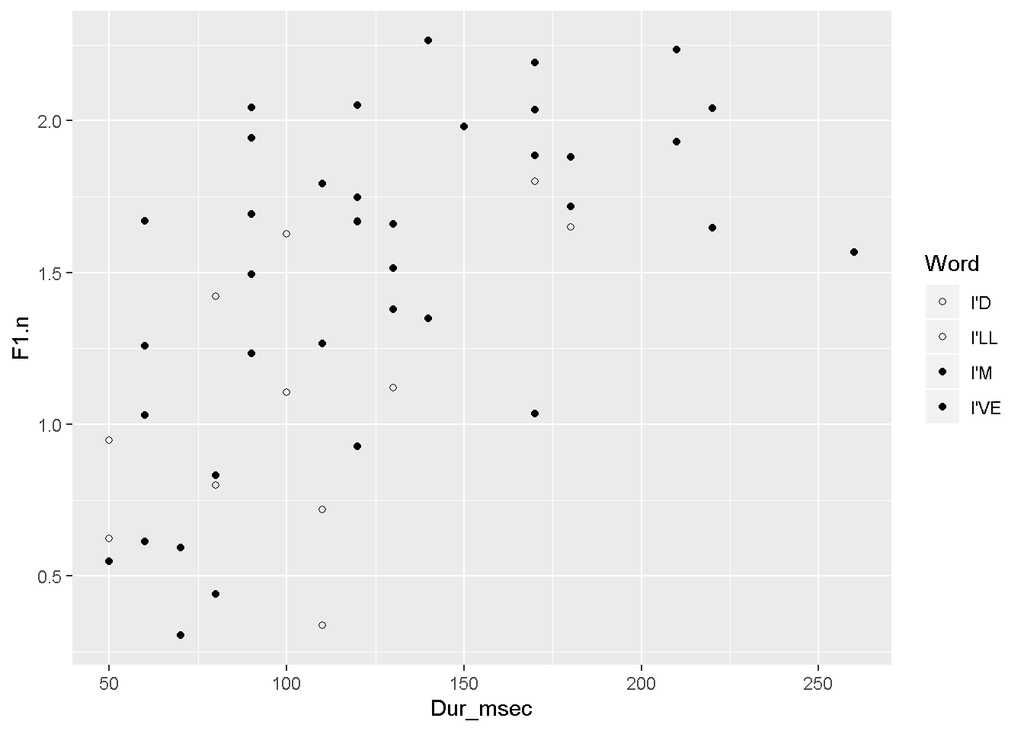

```r
ggplot(I_subset, aes(Dur_msec, F1.n, shape = Word))+
  geom_point()+
  scale_shape_manual(values=c(1,1, 19, 19))
```

### Other scales

```r
apropos("^scale_size_")
```

```
## [1] "scale_size_area"       "scale_size_continuous" "scale_size_date"
## [4] "scale_size_datetime"   "scale_size_discrete"   "scale_size_identity"
## [7] "scale_size_manual"     "scale_size_ordinal"
```

```r
apropos("^scale_alpha_")
```

```
## [1] "scale_alpha_continuous" "scale_alpha_date"       "scale_alpha_datetime"
## [4] "scale_alpha_discrete"   "scale_alpha_identity"   "scale_alpha_manual"
## [7] "scale_alpha_ordinal"
```

### More on Guides

Occasionally, you’ll want to exclude some scale, or some geom from being included in the legend. For example, here’s a plot where color, shape and linetype are all mapped to Word.

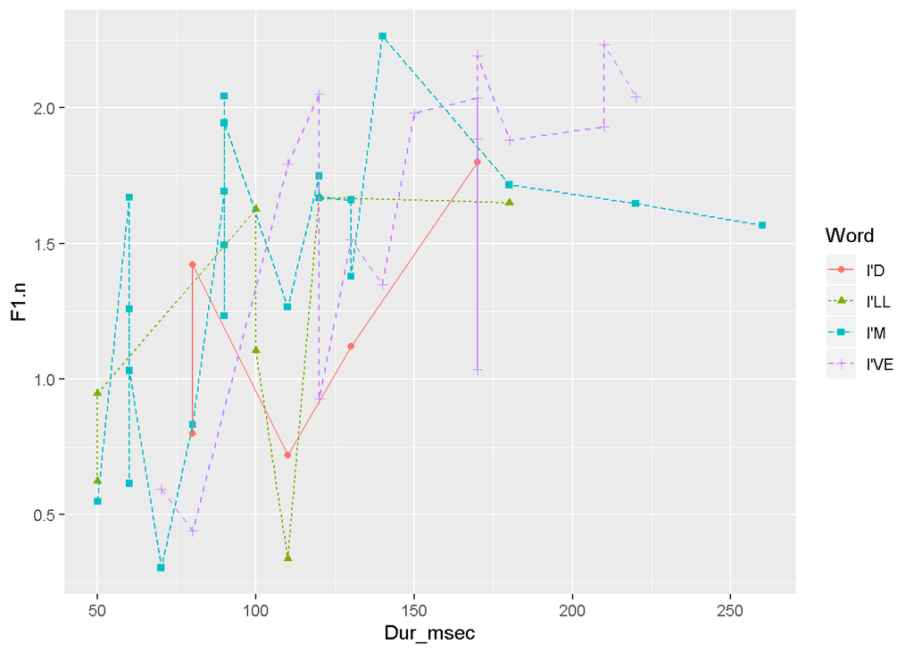

```r
ggplot(I_subset, aes(Dur_msec, F1.n,
                     color = Word,
                     shape = Word,
                     linetype = Word))+
  geom_point()+
  geom_line()
```

If, for some reason, you only wanted the shape and linetype to show up in the legend, but not color, you should explicitly add scale_color_hue() to the plot and pass it guide = F.

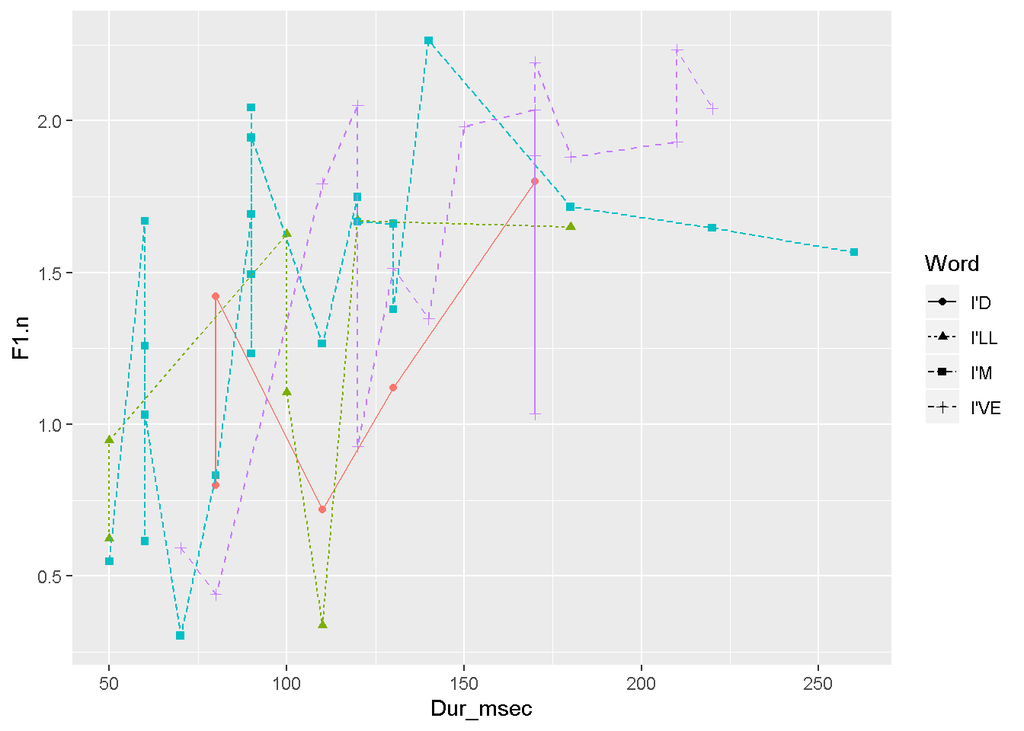

```r
ggplot(I_subset, aes(Dur_msec, F1.n,
                     color = Word,
                     shape = Word,
                     linetype = Word))+
  geom_point()+
  geom_line()+
  scale_color_hue(guide = F)
```

More often, though, you’ll want to exclude specific geoms from being added to the legend. For example, I personally don’t like how geom_text() is represented in legends.

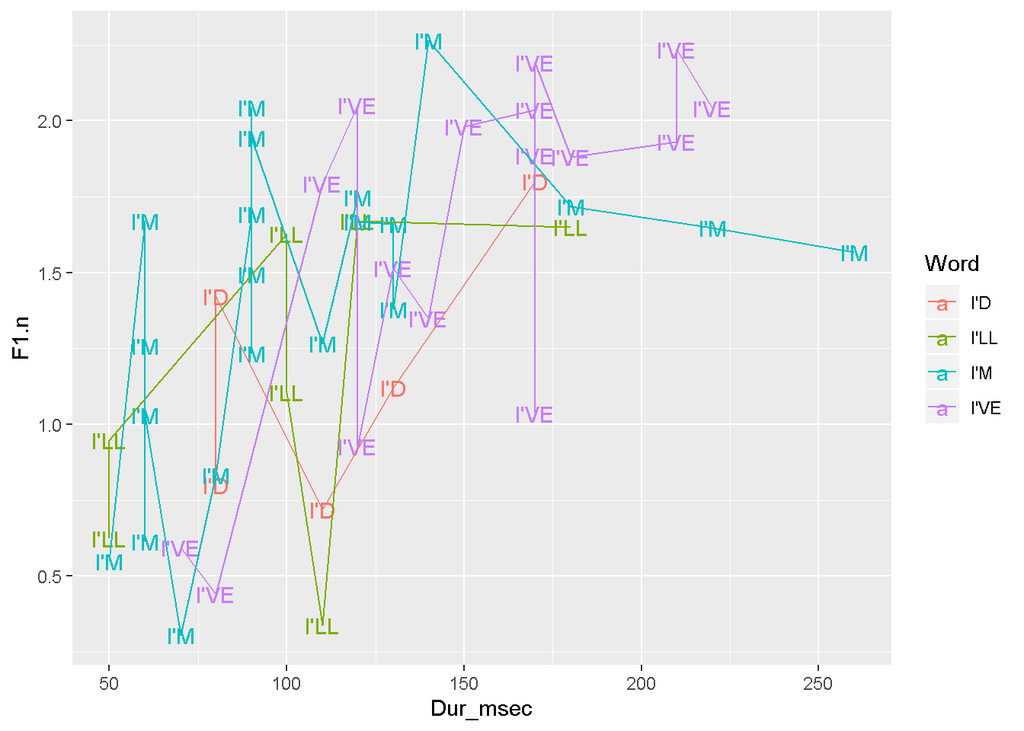

```r
ggplot(I_subset, aes(Dur_msec, F1.n, color = Word, label = Word))+
  geom_text()+
  geom_line()
```

To exclude this geom from appearing in the legend, simply pass show_guide = F to the geom.

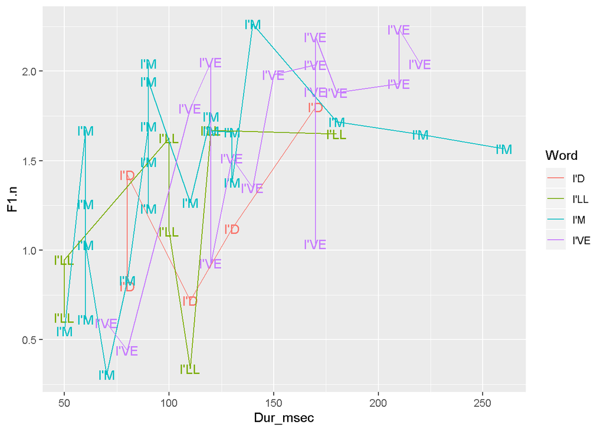

```r
ggplot(I_subset, aes(Dur_msec, F1.n, color = Word, label = Word))+
  geom_text(show_guide = F)+
  geom_line()
```

## Coordinate systems

I don’t have time to go over different coordinate systems in ggplot2, but for the most part everything you’d use them for is already captured by scale transformations. The only exception is coord_polar(), which was demonstrated at the beginning as a way of creating pie charts. But I think it’s just as well because most plots in polar coordinates are inferior to the same plot in Cartesian coordinates,

## Faceting

A really powerful graphical technique is the small multiple, and ggplot2 allows for easy creation of small multiples via faceting. Let’s create an additional categorical variable for the entire data set (we did this already for the subset excluding “I”).

```r
I_jean$Dur_cat <- I_jean$Dur_msec > mean(I_jean$Dur_msec)
```

### facet_wrap

If we wanted to create an F2 x F1 plot for every word, we’d start out by creating a simple F1 x F2 plot:

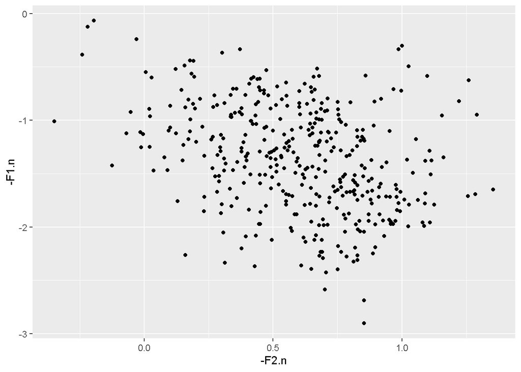

```r
ggplot(I_jean, aes(-F2.n, -F1.n ))+
  geom_point()
```

and then faceting by Word with facet_wrap().

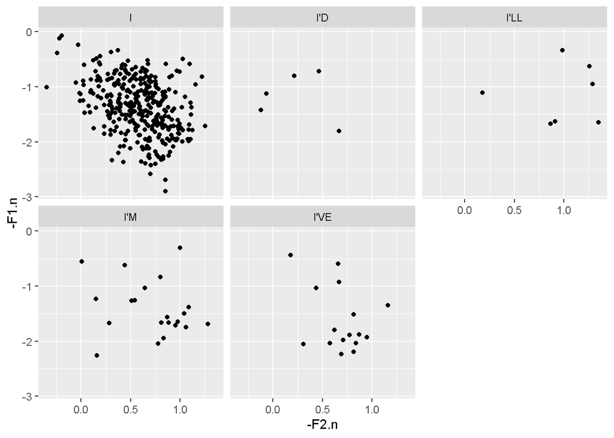

```r
ggplot(I_jean, aes(-F2.n, -F1.n ))+
  geom_point()+
  facet_wrap(~Word)
```

Or, if we wanted summaries of F1 according to Dur_cat for each word, we could do so like this.

[figure not shown]

```r
ggplot(I_jean, aes(Dur_cat, F1.n))+
  stat_summary(fun.data = mean_cl_boot)+
  facet_wrap(~Word)
```

You can exercise some control about the layout of facets with ncol and nrow. For example. if you really only wanted there to be 2 columns of facets, you could make that happen with by passing ncol=2 to facet_wrap()

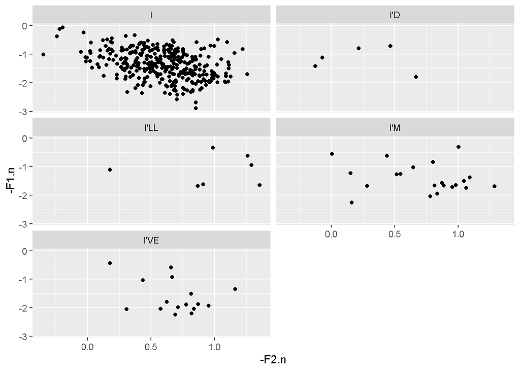

```r
ggplot(I_jean, aes(-F2.n, -F1.n ))+
  geom_point()+
  facet_wrap(~Word, ncol = 2)
```

Or, if you wanted all the facets to be lined up in one row, you would pass nrow = 1.